# Project: Identify Customer Segments

In this project, you will apply unsupervised learning techniques to identify segments of the population that form the core customer base for a mail-order sales company in Germany. These segments can then be used to direct marketing campaigns towards audiences that will have the highest expected rate of returns. The data that you will use has been provided by our partners at Bertelsmann Arvato Analytics, and represents a real-life data science task.

This notebook will help you complete this task by providing a framework within which you will perform your analysis steps. In each step of the project, you will see some text describing the subtask that you will perform, followed by one or more code cells for you to complete your work. **Feel free to add additional code and markdown cells as you go along so that you can explore everything in precise chunks.** The code cells provided in the base template will outline only the major tasks, and will usually not be enough to cover all of the minor tasks that comprise it.

It should be noted that while there will be precise guidelines on how you should handle certain tasks in the project, there will also be places where an exact specification is not provided. **There will be times in the project where you will need to make and justify your own decisions on how to treat the data.** These are places where there may not be only one way to handle the data. In real-life tasks, there may be many valid ways to approach an analysis task. One of the most important things you can do is clearly document your approach so that other scientists can understand the decisions you've made.

At the end of most sections, there will be a Markdown cell labeled **Discussion**. In these cells, you will report your findings for the completed section, as well as document the decisions that you made in your approach to each subtask. **Your project will be evaluated not just on the code used to complete the tasks outlined, but also your communication about your observations and conclusions at each stage.**

```python
# import libraries here; add more as necessary
import numpy as np
import pandas as pd
import matplotlib.pyplot as plt
import seaborn as sns
from sklearn.preprocessing import Imputer
from sklearn import preprocessing
from sklearn.decomposition import PCA
from sklearn.cluster import KMeans

# magic word for producing visualizations in notebook
%matplotlib inline

'''
Import note: The classroom currently uses sklearn version 0.19.
If you need to use an imputer, it is available in sklearn.preprocessing.Imputer,
instead of sklearn.impute as in newer versions of sklearn.
'''
```

```
'\nImport note: The classroom currently uses sklearn version 0.19.\nIf you need to use an imputer, it is available in sklearn.preprocessing.Imputer,\ninstead of sklearn.impute as in newer versions of sklearn.\n'
```

### Step 0: Load the Data

Each row of the demographics files represents a single person, but also includes information outside of individuals, including information about their household, building, and neighborhood. You will use this information to cluster the general population into groups with similar demographic properties. Then, you will see how the people in the customers dataset fit into those created clusters. The hope here is that certain clusters are over-represented in the customers data, as compared to the general population; those over-represented clusters will be assumed to be part of the core userbase. This information can then be used for further applications, such as targeting for a marketing campaign.

To start off with, load in the demographics data for the general population into a pandas DataFrame, and do the same for the feature attributes summary. Note for all of the `.csv` data files in this project: they're semicolon (`;`) delimited, so you'll need an additional argument in your [`read_csv()`](https://pandas.pydata.org/pandas-docs/stable/generated/pandas.read_csv.html) call to read in the data properly. Also, considering the size of the main dataset, it may take some time for it to load completely.

Once the dataset is loaded, it's recommended that you take a little bit of time just browsing the general structure of the dataset and feature summary file. You'll be getting deep into the innards of the cleaning in the first major step of the project, so gaining some general familiarity can help you get your bearings.

```python
# Load in the general demographics data.
azdias = pd.read_csv('Udacity_AZDIAS_Subset.csv', sep=';')
# Load in the feature summary file.
feat_info = pd.read_csv('AZDIAS_Feature_Summary.csv', sep=';')
```

```python
# Check the structure of the data after it's loaded (e.g. print the number of
# rows and columns, print the first few rows).
azdias[:10]
```

|  | AGER_TYP | ALTERSKATEGORIE_GROB | ANREDE_KZ | CJT_GESAMTTYP | FINANZ_MINIMALIST | FINANZ_SPARER | FINANZ_VORSORGER | FINANZ_ANLEGER | FINANZ_UNAUFFAELLIGER | FINANZ_HAUSBAUER | ... | PLZ8_ANTG1 | PLZ8_ANTG2 | PLZ8_ANTG3 | PLZ8_ANTG4 | PLZ8_BAUMAX | PLZ8_HHZ | PLZ8_GBZ | ARBEIT | ORTSGR_KLS9 | RELAT_AB |
| --- | --- | --- | --- | --- | --- | --- | --- | --- | --- | --- | --- | --- | --- | --- | --- | --- | --- | --- | --- | --- | --- |
| 0 | -1 | 2 | 1 | 2.0 | 3 | 4 | 3 | 5 | 5 | 3 | ... | NaN | NaN | NaN | NaN | NaN | NaN | NaN | NaN | NaN | NaN |
| 1 | -1 | 1 | 2 | 5.0 | 1 | 5 | 2 | 5 | 4 | 5 | ... | 2.0 | 3.0 | 2.0 | 1.0 | 1.0 | 5.0 | 4.0 | 3.0 | 5.0 | 4.0 |
| 2 | -1 | 3 | 2 | 3.0 | 1 | 4 | 1 | 2 | 3 | 5 | ... | 3.0 | 3.0 | 1.0 | 0.0 | 1.0 | 4.0 | 4.0 | 3.0 | 5.0 | 2.0 |
| 3 | 2 | 4 | 2 | 2.0 | 4 | 2 | 5 | 2 | 1 | 2 | ... | 2.0 | 2.0 | 2.0 | 0.0 | 1.0 | 3.0 | 4.0 | 2.0 | 3.0 | 3.0 |
| 4 | -1 | 3 | 1 | 5.0 | 4 | 3 | 4 | 1 | 3 | 2 | ... | 2.0 | 4.0 | 2.0 | 1.0 | 2.0 | 3.0 | 3.0 | 4.0 | 6.0 | 5.0 |
| 5 | 3 | 1 | 2 | 2.0 | 3 | 1 | 5 | 2 | 2 | 5 | ... | 2.0 | 3.0 | 1.0 | 1.0 | 1.0 | 5.0 | 5.0 | 2.0 | 3.0 | 3.0 |
| 6 | -1 | 2 | 2 | 5.0 | 1 | 5 | 1 | 5 | 4 | 3 | ... | 3.0 | 3.0 | 1.0 | 0.0 | 1.0 | 5.0 | 5.0 | 4.0 | 6.0 | 3.0 |
| 7 | -1 | 1 | 1 | 3.0 | 3 | 3 | 4 | 1 | 3 | 2 | ... | 3.0 | 3.0 | 1.0 | 0.0 | 1.0 | 4.0 | 4.0 | 2.0 | 5.0 | 2.0 |
| 8 | -1 | 3 | 1 | 3.0 | 4 | 4 | 2 | 4 | 2 | 2 | ... | 2.0 | 3.0 | 2.0 | 1.0 | 1.0 | 3.0 | 3.0 | 2.0 | 4.0 | 3.0 |
| 9 | -1 | 3 | 2 | 4.0 | 2 | 4 | 2 | 3 | 5 | 4 | ... | 2.0 | 3.0 | 2.0 | 1.0 | 1.0 | 3.0 | 3.0 | 2.0 | 3.0 | 1.0 |

10 rows × 85 columns

```python
rows_amount, columns_amount = len(azdias.index), len(azdias.columns)
data_volume = rows_amount * columns_amount
rows_amount, columns_amount, data_volume
```

```
(891221, 85, 75753785)
```

```python
feat_info.head()
```

|  | attribute | information_level | type | missing_or_unknown |
| --- | --- | --- | --- | --- |
| 0 | AGER_TYP | person | categorical | [-1,0] |
| 1 | ALTERSKATEGORIE_GROB | person | ordinal | [-1,0,9] |
| 2 | ANREDE_KZ | person | categorical | [-1,0] |
| 3 | CJT_GESAMTTYP | person | categorical | [0] |
| 4 | FINANZ_MINIMALIST | person | ordinal | [-1] |

```python
features_amount = len(feat_info)
features_amount
```

```
85
```

```python
inf_level_groups = feat_info.groupby('information_level')
print(f'FEATURES GROUPS ({len(inf_level_groups.groups)}):\n', *inf_level_groups.groups.keys(), sep='\n')
```

```
FEATURES GROUPS (9):

building
community
household
macrocell_plz8
microcell_rr3
microcell_rr4
person
postcode
region_rr1
```

> **Tip**: Add additional cells to keep everything in reasonably-sized chunks! Keyboard shortcut `esc --> a` (press escape to enter command mode, then press the 'A' key) adds a new cell before the active cell, and `esc --> b` adds a new cell after the active cell. If you need to convert an active cell to a markdown cell, use `esc --> m` and to convert to a code cell, use `esc --> y`.

## Step 1: Preprocessing

### Step 1.1: Assess Missing Data

The feature summary file contains a summary of properties for each demographics data column. You will use this file to help you make cleaning decisions during this stage of the project. First of all, you should assess the demographics data in terms of missing data. Pay attention to the following points as you perform your analysis, and take notes on what you observe. Make sure that you fill in the **Discussion** cell with your findings and decisions at the end of each step that has one!

#### Step 1.1.1: Convert Missing Value Codes to NaNs

The fourth column of the feature attributes summary (loaded in above as `feat_info`) documents the codes from the data dictionary that indicate missing or unknown data. While the file encodes this as a list (e.g. `[-1,0]`), this will get read in as a string object. You'll need to do a little bit of parsing to make use of it to identify and clean the data. Convert data that matches a 'missing' or 'unknown' value code into a numpy NaN value. You might want to see how much data takes on a 'missing' or 'unknown' code, and how much data is naturally missing, as a point of interest.

**As one more reminder, you are encouraged to add additional cells to break up your analysis into manageable chunks.**

```python
# Identify missing or unknown data values and convert them to NaNs.
```

```python
# Let's define different groups of missing values
feat_info.groupby('missing_or_unknown').groups
```

```
{'[-1,0,9]': Int64Index([1], dtype='int64'),
 '[-1,0]': Int64Index([0, 2, 14, 21, 22, 40, 46, 48, 49, 52, 64, 65, 70, 73, 79, 83], dtype='int64'),
 '[-1,9]': Int64Index([24, 25, 26, 27, 28, 29, 30, 31, 32, 33, 34, 35, 36, 37, 42, 82,
             84],
            dtype='int64'),
 '[-1,XX]': Int64Index([59], dtype='int64'),
 '[-1,X]': Int64Index([57], dtype='int64'),
 '[-1]': Int64Index([ 4,  5,  6,  7,  8,  9, 10, 38, 39, 41, 47, 55, 56, 60, 61, 62, 63,
             66, 67, 68, 75, 76, 77, 78, 80, 81],
            dtype='int64'),
 '[0]': Int64Index([3, 11, 15, 16, 17, 18, 19, 20, 23, 43, 50, 54], dtype='int64'),
 '[XX]': Int64Index([58], dtype='int64'),
 '[]': Int64Index([12, 13, 44, 45, 51, 53, 69, 71, 72, 74], dtype='int64')}
```

```python
# Now let's figure out the data type of this recordings ([-1, 0, 9])
type(feat_info['missing_or_unknown'][0])
```

```
str
```

*The idea is to run through the rows and replace missing or unknown data by NaNs (according to the table)*

```python
def str_to_array(s):
    if s == '[0]':
        return ['0']
    elif s == '[XX]':
        return ['XX']
    elif s == '[]':
        return []
    elif s == '[-1]':
        return ['-1']
    else:
        return s[1:-1].split(',')
```

```python
def replace_to_nans(ds, feat_info):
    nans_amount = 0
    for col in ds.columns:
        missing_def = str_to_array(feat_info[feat_info['attribute'] == col]['missing_or_unknown'].values[0])
        ds[col] = ds[col].apply(lambda x: np.nan if str(x) in missing_def else x)
        nans_amount += ds[col].isna().sum()
    return ds, nans_amount
```

```python
ds, nans_amount = replace_to_nans(azdias, feat_info)
```

```python
ds.head()
```

|  | AGER_TYP | ALTERSKATEGORIE_GROB | ANREDE_KZ | CJT_GESAMTTYP | FINANZ_MINIMALIST | FINANZ_SPARER | FINANZ_VORSORGER | FINANZ_ANLEGER | FINANZ_UNAUFFAELLIGER | FINANZ_HAUSBAUER | ... | PLZ8_ANTG1 | PLZ8_ANTG2 | PLZ8_ANTG3 | PLZ8_ANTG4 | PLZ8_BAUMAX | PLZ8_HHZ | PLZ8_GBZ | ARBEIT | ORTSGR_KLS9 | RELAT_AB |
| --- | --- | --- | --- | --- | --- | --- | --- | --- | --- | --- | --- | --- | --- | --- | --- | --- | --- | --- | --- | --- | --- |
| 0 | NaN | 2.0 | 1 | 2.0 | 3 | 4 | 3 | 5 | 5 | 3 | ... | NaN | NaN | NaN | NaN | NaN | NaN | NaN | NaN | NaN | NaN |
| 1 | NaN | 1.0 | 2 | 5.0 | 1 | 5 | 2 | 5 | 4 | 5 | ... | 2.0 | 3.0 | 2.0 | 1.0 | 1.0 | 5.0 | 4.0 | 3.0 | 5.0 | 4.0 |
| 2 | NaN | 3.0 | 2 | 3.0 | 1 | 4 | 1 | 2 | 3 | 5 | ... | 3.0 | 3.0 | 1.0 | 0.0 | 1.0 | 4.0 | 4.0 | 3.0 | 5.0 | 2.0 |
| 3 | 2.0 | 4.0 | 2 | 2.0 | 4 | 2 | 5 | 2 | 1 | 2 | ... | 2.0 | 2.0 | 2.0 | 0.0 | 1.0 | 3.0 | 4.0 | 2.0 | 3.0 | 3.0 |
| 4 | NaN | 3.0 | 1 | 5.0 | 4 | 3 | 4 | 1 | 3 | 2 | ... | 2.0 | 4.0 | 2.0 | 1.0 | 2.0 | 3.0 | 3.0 | 4.0 | 6.0 | 5.0 |

5 rows × 85 columns

```python
print(f'{round(nans_amount / data_volume * 100, 2)}% of data is missed.')
```

```
8.62% of data is missed.
```

#### Step 1.1.2: Assess Missing Data in Each Column

How much missing data is present in each column? There are a few columns that are outliers in terms of the proportion of values that are missing. You will want to use matplotlib's [`hist()`](https://matplotlib.org/api/_as_gen/matplotlib.pyplot.hist.html) function to visualize the distribution of missing value counts to find these columns. Identify and document these columns. While some of these columns might have justifications for keeping or re-encoding the data, for this project you should just remove them from the dataframe. (Feel free to make remarks about these outlier columns in the discussion, however!)

For the remaining features, are there any patterns in which columns have, or share, missing data?

*Let's explore all the features (columns) that we have. We will find the amount of missed values in each column and then, we will find their percentage to the amount of data in the next cell. Let's print them in descending order:*

```python
# Investigate patterns in the amount of missing data in each column.

missing_data = ds.isna().sum() / rows_amount
missing_data = missing_data.sort_values(ascending=False)
```

*Top-5 most 'missed-data' columns are:*

```python
missing_data.head()
```

```
AGER_TYP        0.769554
KK_KUNDENTYP    0.655967
GEBURTSJAHR     0.440203
KBA05_ANTG1     0.149597
KBA05_BAUMAX    0.149597
dtype: float64
```

I decided to make the visualization that shows missed data percentages for each feature. This is a horizontal bar. The X-axis shows the percentage and Y-axis shows the corresponding feature. The dashed line shows the percentage equals 0.5. It means, that the values to the right of the line match the features with >50% missed data.

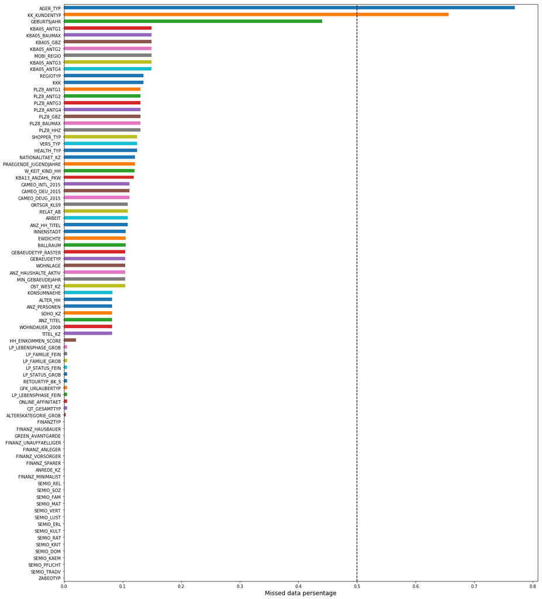

```python
fig, ax = plt.subplots()
plt.xlabel("Missed data persentage", fontsize=14)
fig.set_figwidth(20)
fig.set_figheight(25)

ax = missing_data.plot(kind='barh')
ax.invert_yaxis()
plt.axvline(x=0.5, color='black', linestyle='--')
```

```python
# Remove the outlier columns from the dataset. (You'll perform other data
# engineering tasks such as re-encoding and imputation later.)

top_3_missed = missing_data.index[:3]
print(*top_3_missed, sep='\n')
```

```
AGER_TYP
KK_KUNDENTYP
GEBURTSJAHR
```

Let's take a look at Data_Dictionary.md.

1. AGER_TYP - Best-ager typology. This feature is informative only for elderly people. That's why a lot of data is missed (76.95%!). Let me assume that it makes sense to drop it.
2. KK_KUNDENTYP - Consumer pattern over past 12 months (regular customer, active customer, new costumer, etc.). That's very pity that a lot of data missed (65.59%). But there is an alternative feature - CJT_GESAMTTYP (Customer-Journey-Typology) that may give a lot of useful information about customers. So we will drop KK_KUNDENTYP feature from the table.
3. GEBURTSJAHR - Year of birth. That is very important demographic feature, so we won't drop it despite the fact that 44.02% of data is missed.

```python
features_to_drop = list(missing_data.index[:2])
ds = ds.drop(columns=features_to_drop)
```

*Let's find out now how much missed data left is in the dataset:*

```python
new_rows_amount, new_columns_amount = len(ds.index), len(ds.columns)
new_data_volume = new_rows_amount * new_columns_amount
round(100 - new_data_volume / data_volume * 100, 2)
```

```
2.35
```

```python
print(f'{round(ds.isnull().sum().sum() / new_data_volume * 100, 2)}% of data is missed.')
```

```
7.11% of data is missed.
```

**Before dropping the features, it was 8.62% of missed data. We reduced missed data by 1.51% and the total amount of data reduced by 2.35%.**

Ok. Let's continue investigating the data and answer the following question:

*For the remaining features, are there any patterns in which columns have, or share, missing data?*

Let's try to name all the features that probably share data (with the help of Data Dictionary):

1. FINANZ_MINIMALIST, FINANZ_SPARER, FINANZ_VORSORGER, FINANZ_ANLEGER, FINANZ_UNAUFFAELLIGER, FINANZ_HAUSBAUER and FINANZTYP - all these features are about Financial typology (very high, high, average, low, very low). MINIMALIST: low financial interest, SPARER: money-saver, VORSORGER: be prepared, ANLEGER: investor, UNAUFFAELLIGER: inconspicuous, HAUSBAUER: home ownership. The feature FINANZTYP describes the most descriptive financial type for individual. In order to simplify our research or just make the data simplier, it's permissible to drop all the FINANZ_X features and left only FINANZTYPE feature.

```python
features_to_drop = ['FINANZ_MINIMALIST', 'FINANZ_SPARER', 'FINANZ_VORSORGER', 'FINANZ_ANLEGER', 'FINANZ_UNAUFFAELLIGER', 'FINANZ_HAUSBAUER']
ds = ds.drop(columns=features_to_drop)
```

A set of very similar features - LP_STATUS_FEIN and LP_STATUS_GROB, LP_FAMILIE_FEIN and LP_FAMILIE_GROB, LP_LEBENSPHASE_FEIN and LP_LEBENSPHASE_GROB. FINE means the fine-scale, GROB means the rough scale. To simplify the research, we can leave only FEIN features. So let's drop other features.

```python
features_to_drop = ['LP_STATUS_GROB', 'LP_FAMILIE_GROB', 'LP_LEBENSPHASE_GROB']
ds = ds.drop(columns=features_to_drop)
```

What about features that start with PLZ8_ANTG. Let's take a look at Data Dictionary. All the features PLZ8 mean the Number of X-Y family houses in the PLZ8 region. We can aggregate these features with one: PLZ8_BAUMAX, which estimates the average number of family houses and drop less important features. We also will left PLZ8_HHZ, PLZ8_GBZ, KBA13_ANZAHL_PKW features.

```python
features_to_drop = ['PLZ8_ANTG1', 'PLZ8_ANTG2', 'PLZ8_ANTG3', 'PLZ8_ANTG4']
ds = ds.drop(columns=features_to_drop)
```

```python
ds.head()
```

|  | ALTERSKATEGORIE_GROB | ANREDE_KZ | CJT_GESAMTTYP | FINANZTYP | GEBURTSJAHR | GFK_URLAUBERTYP | GREEN_AVANTGARDE | HEALTH_TYP | LP_LEBENSPHASE_FEIN | LP_FAMILIE_FEIN | ... | MOBI_REGIO | ONLINE_AFFINITAET | REGIOTYP | KBA13_ANZAHL_PKW | PLZ8_BAUMAX | PLZ8_HHZ | PLZ8_GBZ | ARBEIT | ORTSGR_KLS9 | RELAT_AB |
| --- | --- | --- | --- | --- | --- | --- | --- | --- | --- | --- | --- | --- | --- | --- | --- | --- | --- | --- | --- | --- | --- |
| 0 | 2.0 | 1 | 2.0 | 4 | NaN | 10.0 | 0 | NaN | 15.0 | 2.0 | ... | NaN | 1.0 | NaN | NaN | NaN | NaN | NaN | NaN | NaN | NaN |
| 1 | 1.0 | 2 | 5.0 | 1 | 1996.0 | 10.0 | 0 | 3.0 | 21.0 | 5.0 | ... | 1.0 | 3.0 | 3.0 | 963.0 | 1.0 | 5.0 | 4.0 | 3.0 | 5.0 | 4.0 |
| 2 | 3.0 | 2 | 3.0 | 1 | 1979.0 | 10.0 | 1 | 3.0 | 3.0 | 1.0 | ... | 3.0 | 2.0 | 2.0 | 712.0 | 1.0 | 4.0 | 4.0 | 3.0 | 5.0 | 2.0 |
| 3 | 4.0 | 2 | 2.0 | 6 | 1957.0 | 1.0 | 0 | 2.0 | 0.0 | 0.0 | ... | 4.0 | 1.0 | 0.0 | 596.0 | 1.0 | 3.0 | 4.0 | 2.0 | 3.0 | 3.0 |
| 4 | 3.0 | 1 | 5.0 | 5 | 1963.0 | 5.0 | 0 | 3.0 | 32.0 | 10.0 | ... | 3.0 | 5.0 | 5.0 | 435.0 | 2.0 | 3.0 | 3.0 | 4.0 | 6.0 | 5.0 |

5 rows × 70 columns

```python
new_rows_amount_2, new_columns_amount_2 = len(ds.index), len(ds.columns)
new_data_volume_2 = new_rows_amount_2 * new_columns_amount_2
round(100 - new_data_volume_2 / new_data_volume * 100, 2)
```

```
15.66
```

The amount of data reduced by 15.66%! Ok, what about missing data?

```python
print(f'{round(ds.isnull().sum().sum() / new_data_volume_2 * 100, 2)}% of data is missed.')
```

```
7.66% of data is missed.
```

In the beginning, it was 8.62% of missed data. After dropping most-missed features, it was 7.11% of missed data. Now, this percent increased because we dropped a lot of similar features and now this percent is 7.66%.

#### Discussion 1.1.2: Assess Missing Data in Each Column

(Double click this cell and replace this text with your own text, reporting your observations regarding the amount of missing data in each column. Are there any patterns in missing values? Which columns were removed from the dataset?)

#### Step 1.1.3: Assess Missing Data in Each Row

Now, you'll perform a similar assessment for the rows of the dataset. How much data is missing in each row? As with the columns, you should see some groups of points that have a very different numbers of missing values. Divide the data into two subsets: one for data points that are above some threshold for missing values, and a second subset for points below that threshold.

In order to know what to do with the outlier rows, we should see if the distribution of data values on columns that are not missing data (or are missing very little data) are similar or different between the two groups. Select at least five of these columns and compare the distribution of values.

- You can use seaborn's [`countplot()`](https://seaborn.pydata.org/generated/seaborn.countplot.html) function to create a bar chart of code frequencies and matplotlib's [`subplot()`](https://matplotlib.org/api/_as_gen/matplotlib.pyplot.subplot.html) function to put bar charts for the two subplots side by side.
- To reduce repeated code, you might want to write a function that can perform this comparison, taking as one of its arguments a column to be compared.

Depending on what you observe in your comparison, this will have implications on how you approach your conclusions later in the analysis. If the distributions of non-missing features look similar between the data with many missing values and the data with few or no missing values, then we could argue that simply dropping those points from the analysis won't present a major issue. On the other hand, if the data with many missing values looks very different from the data with few or no missing values, then we should make a note on those data as special. We'll revisit these data later on. **Either way, you should continue your analysis for now using just the subset of the data with few or no missing values.**

```python
# How much data is missing in each row of the dataset
missing_rows = ds.isnull().sum(axis=1).sort_values(ascending=False)
missing_rows.head(), missing_rows.tail()
```

```
(0         43
 171988    43
 768629    43
 448533    43
 768642    43
 dtype: int64, 326696    0
 326697    0
 326698    0
 657555    0
 445610    0
 dtype: int64)
```

*Firstly, I want to see the distribution of missed values along all the columns*

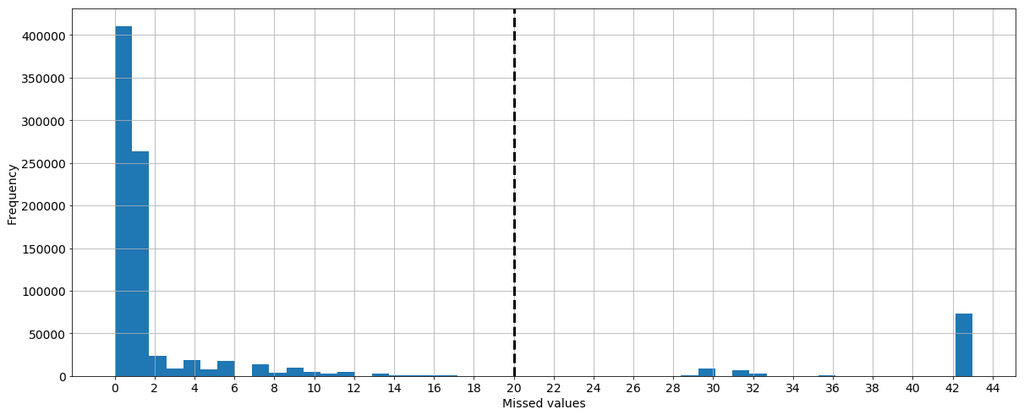

```python
fig, ax = plt.subplots()
plt.xlabel("Missed values", fontsize=14)
plt.ylabel("Frequency", fontsize=14)
plt.xticks(range(0, 50, 2), fontsize=14)
plt.yticks(fontsize=14)

fig.set_figwidth(20)
fig.set_figheight(8)

missing_rows.plot(kind='hist', bins=50)
plt.axvline(x=20, color='black', linestyle='--', linewidth=3)
plt.grid()
```

```python
# Write code to divide the data into two subsets based on the number of missing
# values in each row.
subset_1, subset_2 = ds[ds.isnull().sum(axis=1) > 20], ds[ds.isnull().sum(axis=1) <= 20]
```

```python
# Compare the distribution of values for at least five columns where there are
# no or few missing values, between the two subsets.
selected_columns = ['SEMIO_ERL', 'GFK_URLAUBERTYP', 'LP_LEBENSPHASE_FEIN', 'CJT_GESAMTTYP', 'RETOURTYP_BK_S']
filtered_subset_1 = subset_1[selected_columns]
filtered_subset_2 = subset_2[selected_columns]
```

```python
def compare(feature, ss1, ss2):
    fig, axs = plt.subplots(1, 2)
    fig.suptitle(f'{feature} distribution', fontsize=16)
    fig.set_figwidth(24)
    fig.set_figheight(6)
    axs[0].set_title('Missed data in > 20 features')
    axs[1].set_title('Missed data in <= 20')
    axs[0].hist(ss1[feature].fillna(-1))
    axs[1].hist(ss2[feature].fillna(-1))
```

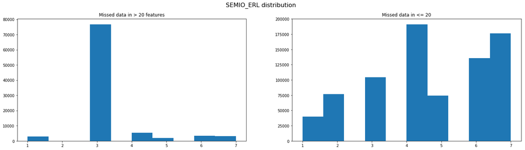

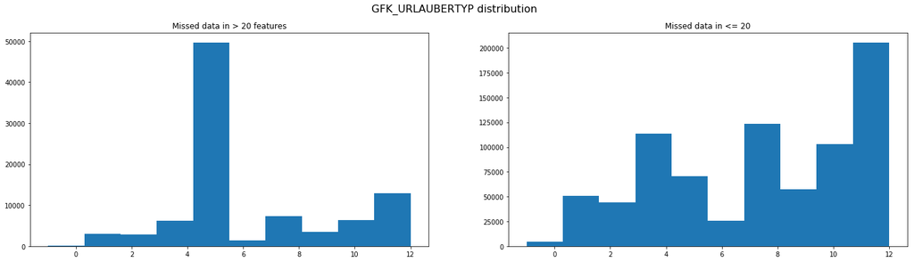

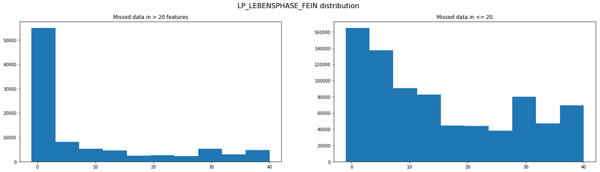

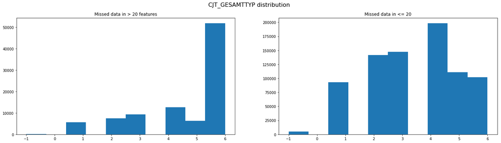

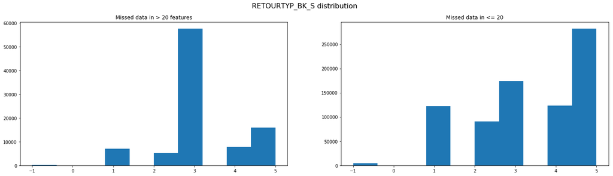

```python
for col in selected_columns:
    compare(col, filtered_subset_1, filtered_subset_2)
```

```python
ds = subset_2
```

```python
print(f'Subset_2 is {round(len(subset_2) / new_rows_amount * 100, 2)}% of initial data')
```

```
Subset_2 is 89.54% of initial data
```

#### Discussion 1.1.3: Assess Missing Data in Each Row

(Double-click this cell and replace this text with your own text, reporting your observations regarding missing data in rows. Are the data with lots of missing values are qualitatively different from data with few or no missing values?)

**Answer:** Data distributions of two subsets (with a large and a small number of gaps) look different.

### Step 1.2: Select and Re-Encode Features

Checking for missing data isn't the only way in which you can prepare a dataset for analysis. Since the unsupervised learning techniques to be used will only work on data that is encoded numerically, you need to make a few encoding changes or additional assumptions to be able to make progress. In addition, while almost all of the values in the dataset are encoded using numbers, not all of them represent numeric values. Check the third column of the feature summary (`feat_info`) for a summary of types of measurement.

- For numeric and interval data, these features can be kept without changes.
- Most of the variables in the dataset are ordinal in nature. While ordinal values may technically be non-linear in spacing, make the simplifying assumption that the ordinal variables can be treated as being interval in nature (that is, kept without any changes).
- Special handling may be necessary for the remaining two variable types: categorical, and 'mixed'.

In the first two parts of this sub-step, you will perform an investigation of the categorical and mixed-type features and make a decision on each of them, whether you will keep, drop, or re-encode each. Then, in the last part, you will create a new data frame with only the selected and engineered columns.

Data wrangling is often the trickiest part of the data analysis process, and there's a lot of it to be done here. But stick with it: once you're done with this step, you'll be ready to get to the machine learning parts of the project!

```python
# How many features are there of each data type?

# Initial features
feat_info.groupby('type')['attribute'].count()
```

```
type
categorical    21
interval        1
mixed           7
numeric         7
ordinal        49
Name: attribute, dtype: int64
```

```python
new_features = feat_info[feat_info['attribute'].isin(list(ds.columns))]
len(new_features)
```

```
70
```

```python
# New features (after dropping)
new_features.groupby('type')['attribute'].count()
```

```
type
categorical    17
interval        1
mixed           6
numeric         7
ordinal        39
Name: attribute, dtype: int64
```

#### Step 1.2.1: Re-Encode Categorical Features

For categorical data, you would ordinarily need to encode the levels as dummy variables. Depending on the number of categories, perform one of the following:

- For binary (two-level) categoricals that take numeric values, you can keep them without needing to do anything.
- There is one binary variable that takes on non-numeric values. For this one, you need to re-encode the values as numbers or create a dummy variable.
- For multi-level categoricals (three or more values), you can choose to encode the values using multiple dummy variables (e.g. via [OneHotEncoder](http://scikit-learn.org/stable/modules/generated/sklearn.preprocessing.OneHotEncoder.html)), or (to keep things straightforward) just drop them from the analysis. As always, document your choices in the Discussion section.

```python
ds[new_features[new_features['type'] == 'categorical']['attribute']].head()
```

|  | ANREDE_KZ | CJT_GESAMTTYP | FINANZTYP | GFK_URLAUBERTYP | GREEN_AVANTGARDE | LP_FAMILIE_FEIN | LP_STATUS_FEIN | NATIONALITAET_KZ | SHOPPER_TYP | SOHO_KZ | TITEL_KZ | VERS_TYP | ZABEOTYP | GEBAEUDETYP | OST_WEST_KZ | CAMEO_DEUG_2015 | CAMEO_DEU_2015 |
| --- | --- | --- | --- | --- | --- | --- | --- | --- | --- | --- | --- | --- | --- | --- | --- | --- | --- |
| 1 | 2 | 5.0 | 1 | 10.0 | 0 | 5.0 | 2.0 | 1.0 | 3.0 | 1.0 | 0.0 | 2.0 | 5 | 8.0 | W | 8 | 8A |
| 2 | 2 | 3.0 | 1 | 10.0 | 1 | 1.0 | 3.0 | 1.0 | 2.0 | 0.0 | 0.0 | 1.0 | 5 | 1.0 | W | 4 | 4C |
| 3 | 2 | 2.0 | 6 | 1.0 | 0 | 0.0 | 9.0 | 1.0 | 1.0 | 0.0 | 0.0 | 1.0 | 3 | 1.0 | W | 2 | 2A |
| 4 | 1 | 5.0 | 5 | 5.0 | 0 | 10.0 | 3.0 | 1.0 | 2.0 | 0.0 | 0.0 | 2.0 | 4 | 1.0 | W | 6 | 6B |
| 5 | 2 | 2.0 | 2 | 1.0 | 0 | 1.0 | 4.0 | 1.0 | 0.0 | 0.0 | 0.0 | 2.0 | 4 | 1.0 | W | 8 | 8C |

*Assess categorical variables: which are binary, which are multi-level, and which one needs to be re-encoded?*

```python
# Re-encode categorical variable(s) to be kept in the analysis.
ds['OST_WEST_KZ'] = ds['OST_WEST_KZ'].apply(lambda x: 0 if x == 'W' else (1 if x == 'O' else np.nan))
```

```python
ds[new_features[new_features['type'] == 'categorical']['attribute']].head()
```

|  | ANREDE_KZ | CJT_GESAMTTYP | FINANZTYP | GFK_URLAUBERTYP | GREEN_AVANTGARDE | LP_FAMILIE_FEIN | LP_STATUS_FEIN | NATIONALITAET_KZ | SHOPPER_TYP | SOHO_KZ | TITEL_KZ | VERS_TYP | ZABEOTYP | GEBAEUDETYP | OST_WEST_KZ | CAMEO_DEUG_2015 | CAMEO_DEU_2015 |
| --- | --- | --- | --- | --- | --- | --- | --- | --- | --- | --- | --- | --- | --- | --- | --- | --- | --- |
| 1 | 2 | 5.0 | 1 | 10.0 | 0 | 5.0 | 2.0 | 1.0 | 3.0 | 1.0 | 0.0 | 2.0 | 5 | 8.0 | 0 | 8 | 8A |
| 2 | 2 | 3.0 | 1 | 10.0 | 1 | 1.0 | 3.0 | 1.0 | 2.0 | 0.0 | 0.0 | 1.0 | 5 | 1.0 | 0 | 4 | 4C |
| 3 | 2 | 2.0 | 6 | 1.0 | 0 | 0.0 | 9.0 | 1.0 | 1.0 | 0.0 | 0.0 | 1.0 | 3 | 1.0 | 0 | 2 | 2A |
| 4 | 1 | 5.0 | 5 | 5.0 | 0 | 10.0 | 3.0 | 1.0 | 2.0 | 0.0 | 0.0 | 2.0 | 4 | 1.0 | 0 | 6 | 6B |
| 5 | 2 | 2.0 | 2 | 1.0 | 0 | 1.0 | 4.0 | 1.0 | 0.0 | 0.0 | 0.0 | 2.0 | 4 | 1.0 | 0 | 8 | 8C |

```python
ds.groupby(['CAMEO_DEU_2015']).ngroups
```

```
44
```

```python
ds = ds.drop(['CAMEO_DEU_2015'], axis=1)
ds.head()
```

|  | ALTERSKATEGORIE_GROB | ANREDE_KZ | CJT_GESAMTTYP | FINANZTYP | GEBURTSJAHR | GFK_URLAUBERTYP | GREEN_AVANTGARDE | HEALTH_TYP | LP_LEBENSPHASE_FEIN | LP_FAMILIE_FEIN | ... | MOBI_REGIO | ONLINE_AFFINITAET | REGIOTYP | KBA13_ANZAHL_PKW | PLZ8_BAUMAX | PLZ8_HHZ | PLZ8_GBZ | ARBEIT | ORTSGR_KLS9 | RELAT_AB |
| --- | --- | --- | --- | --- | --- | --- | --- | --- | --- | --- | --- | --- | --- | --- | --- | --- | --- | --- | --- | --- | --- |
| 1 | 1.0 | 2 | 5.0 | 1 | 1996.0 | 10.0 | 0 | 3.0 | 21.0 | 5.0 | ... | 1.0 | 3.0 | 3.0 | 963.0 | 1.0 | 5.0 | 4.0 | 3.0 | 5.0 | 4.0 |
| 2 | 3.0 | 2 | 3.0 | 1 | 1979.0 | 10.0 | 1 | 3.0 | 3.0 | 1.0 | ... | 3.0 | 2.0 | 2.0 | 712.0 | 1.0 | 4.0 | 4.0 | 3.0 | 5.0 | 2.0 |
| 3 | 4.0 | 2 | 2.0 | 6 | 1957.0 | 1.0 | 0 | 2.0 | 0.0 | 0.0 | ... | 4.0 | 1.0 | 0.0 | 596.0 | 1.0 | 3.0 | 4.0 | 2.0 | 3.0 | 3.0 |
| 4 | 3.0 | 1 | 5.0 | 5 | 1963.0 | 5.0 | 0 | 3.0 | 32.0 | 10.0 | ... | 3.0 | 5.0 | 5.0 | 435.0 | 2.0 | 3.0 | 3.0 | 4.0 | 6.0 | 5.0 |
| 5 | 1.0 | 2 | 2.0 | 2 | 1943.0 | 1.0 | 0 | 3.0 | 8.0 | 1.0 | ... | 4.0 | 1.0 | 5.0 | 1300.0 | 1.0 | 5.0 | 5.0 | 2.0 | 3.0 | 3.0 |

5 rows × 69 columns

#### Discussion 1.2.1: Re-Encode Categorical Features

(Double-click this cell and replace this text with your own text, reporting your findings and decisions regarding categorical features. Which ones did you keep, which did you drop, and what engineering steps did you perform?)

#### Step 1.2.2: Engineer Mixed-Type Features

There are a handful of features that are marked as "mixed" in the feature summary that require special treatment in order to be included in the analysis. There are two in particular that deserve attention; the handling of the rest are up to your own choices:

- "PRAEGENDE_JUGENDJAHRE" combines information on three dimensions: generation by decade, movement (mainstream vs. avantgarde), and nation (east vs. west). While there aren't enough levels to disentangle east from west, you should create two new variables to capture the other two dimensions: an interval-type variable for decade, and a binary variable for movement.
- "CAMEO_INTL_2015" combines information on two axes: wealth and life stage. Break up the two-digit codes by their 'tens'-place and 'ones'-place digits into two new ordinal variables (which, for the purposes of this project, is equivalent to just treating them as their raw numeric values).
- If you decide to keep or engineer new features around the other mixed-type features, make sure you note your steps in the Discussion section.

Be sure to check `Data_Dictionary.md` for the details needed to finish these tasks.

```python
# Investigate "PRAEGENDE_JUGENDJAHRE" and engineer two new variables.
```

```python
ms_values = np.array([1, 3, 5, 8, 10, 12, 14], dtype='float64')
av_values = np.array([2, 4, 6, 7, 9, 11, 13, 15], dtype='float64')
```

```python
ds['PRAEGENDE_JUGENDJAHRE_MOVEMENT'] = ds['PRAEGENDE_JUGENDJAHRE'].apply(lambda x: 0 if x in ms_values else (1 if x in av_values else np.nan))
```

```python
ds['PRAEGENDE_JUGENDJAHRE_MOVEMENT'][:3]
```

```
1    0.0
2    1.0
3    0.0
Name: PRAEGENDE_JUGENDJAHRE_MOVEMENT, dtype: float64
```

```python
def code_into_decade(code):
    decade_40s, decade_50s, decade_60s, decade_70s, decade_80s, decade_90s = [1, 2], [3, 4], [5, 6, 7], [8, 9], [10, 11, 12, 13], [14, 15]
    if code in decade_40s:
        return 4
    elif code in decade_50s:
        return 5
    elif code in decade_60s:
        return 6
    elif code in decade_70s:
        return 7
    elif code in decade_80s:
        return 8
    elif code in decade_90s:
        return 9
    else:
        return np.nan
```

```python
ds['PRAEGENDE_JUGENDJAHRE_DECADE'] = ds['PRAEGENDE_JUGENDJAHRE'].apply(lambda x: code_into_decade(x))
```

```python
ds = ds.drop(['PRAEGENDE_JUGENDJAHRE'], axis=1)
```

```python
ds.head()
```

|  | ALTERSKATEGORIE_GROB | ANREDE_KZ | CJT_GESAMTTYP | FINANZTYP | GEBURTSJAHR | GFK_URLAUBERTYP | GREEN_AVANTGARDE | HEALTH_TYP | LP_LEBENSPHASE_FEIN | LP_FAMILIE_FEIN | ... | REGIOTYP | KBA13_ANZAHL_PKW | PLZ8_BAUMAX | PLZ8_HHZ | PLZ8_GBZ | ARBEIT | ORTSGR_KLS9 | RELAT_AB | PRAEGENDE_JUGENDJAHRE_MOVEMENT | PRAEGENDE_JUGENDJAHRE_DECADE |
| --- | --- | --- | --- | --- | --- | --- | --- | --- | --- | --- | --- | --- | --- | --- | --- | --- | --- | --- | --- | --- | --- |
| 1 | 1.0 | 2 | 5.0 | 1 | 1996.0 | 10.0 | 0 | 3.0 | 21.0 | 5.0 | ... | 3.0 | 963.0 | 1.0 | 5.0 | 4.0 | 3.0 | 5.0 | 4.0 | 0.0 | 9.0 |
| 2 | 3.0 | 2 | 3.0 | 1 | 1979.0 | 10.0 | 1 | 3.0 | 3.0 | 1.0 | ... | 2.0 | 712.0 | 1.0 | 4.0 | 4.0 | 3.0 | 5.0 | 2.0 | 1.0 | 9.0 |
| 3 | 4.0 | 2 | 2.0 | 6 | 1957.0 | 1.0 | 0 | 2.0 | 0.0 | 0.0 | ... | 0.0 | 596.0 | 1.0 | 3.0 | 4.0 | 2.0 | 3.0 | 3.0 | 0.0 | 7.0 |
| 4 | 3.0 | 1 | 5.0 | 5 | 1963.0 | 5.0 | 0 | 3.0 | 32.0 | 10.0 | ... | 5.0 | 435.0 | 2.0 | 3.0 | 3.0 | 4.0 | 6.0 | 5.0 | 0.0 | 7.0 |
| 5 | 1.0 | 2 | 2.0 | 2 | 1943.0 | 1.0 | 0 | 3.0 | 8.0 | 1.0 | ... | 5.0 | 1300.0 | 1.0 | 5.0 | 5.0 | 2.0 | 3.0 | 3.0 | 0.0 | 5.0 |

5 rows × 70 columns

*Investigate "CAMEO_INTL_2015" and engineer two new variables.*

```python
def wealth_to_code(x):
    return np.float64(str(x)[0]) if not np.isnan(x) else np.nan
```

```python
def lifestate_to_code(x):
    return np.float64(str(x)[1]) if not np.isnan(x) else np.nan
```

```python
# Converting floats to numpy values
ds['CAMEO_INTL_2015'] = ds['CAMEO_INTL_2015'].apply(lambda x: np.float64(x))
```

```python
# Re-encoding of wealth
ds['CAMEO_INTL_2015_WEALTH'] = ds['CAMEO_INTL_2015'].apply(lambda x: wealth_to_code(x))
```

```python
# Re-encoding of lifestate
ds['CAMEO_INTL_2015_LIFESTATE'] = ds['CAMEO_INTL_2015'].apply(lambda x: lifestate_to_code(x))
```

```python
ds['CAMEO_INTL_2015_WEALTH'].head()
```

```
1    5.0
2    2.0
3    1.0
4    4.0
5    5.0
Name: CAMEO_INTL_2015_WEALTH, dtype: float64
```

```python
ds['CAMEO_INTL_2015_LIFESTATE'].head()
```

```
1    1.0
2    4.0
3    2.0
4    3.0
5    4.0
Name: CAMEO_INTL_2015_LIFESTATE, dtype: float64
```

```python
ds = ds.drop(['CAMEO_INTL_2015'], axis=1)
```

```python
len(ds.columns)
```

```
71
```

```python
new_features = feat_info[feat_info['attribute'].isin(list(ds.columns))]
```

#### Discussion 1.2.2: Engineer Mixed-Type Features

(Double-click this cell and replace this text with your own text, reporting your findings and decisions regarding mixed-value features. Which ones did you keep, which did you drop, and what engineering steps did you perform?)

PRAEGENDE_JUGENDJAHRE - Dominating movement of person's youth (avantgarde vs. mainstream; east vs. west). Kinds of values: from 1 to 15 and NaNs. One-hot encoding isn't a good decision. So it's better to split the values into the following groups: Movement and Decade.

CAMEO_INTL_2015 - German CAMEO: Wealth / Life Stage Typology, mapped to international code. Was separeted by two variables: CAMEO_INTL_2015_WEALTH and CAMEO_INTL_2015_LIFESTATE.

1. CAMEO_INTL_2015_WEALTH - Wealthy (1), Prosperous (2), Comfortable (3), Less Affluent (4), Poorer (5) Households. Encoded with getting the first digit from the value that means exactly Wealth level. The whole column was re-encoded with the help of the function *wealth_to_code(x)*
2. CAMEO_INTL_2015_LIFESTATE - Pre-Family Couples & Singles (1), Young Couples With Children (2), Families With School-Age Children (3), Older Families & Mature Couples (4), Elders In Retirement (5). Encoded with getting the second digit from the value that means exactly Life (family) state. The whole column was re-encoded with the help of the function *lifestate_to_code(x)*

Finally, I dropped the column CAMEO_INTL_2015.

#### Step 1.2.3: Complete Feature Selection

In order to finish this step up, you need to make sure that your data frame now only has the columns that you want to keep. To summarize, the dataframe should consist of the following:

- All numeric, interval, and ordinal type columns from the original dataset.
- Binary categorical features (all numerically-encoded).
- Engineered features from other multi-level categorical features and mixed features.

Make sure that for any new columns that you have engineered, that you've excluded the original columns from the final dataset. Otherwise, their values will interfere with the analysis later on the project. For example, you should not keep "PRAEGENDE_JUGENDJAHRE", since its values won't be useful for the algorithm: only the values derived from it in the engineered features you created should be retained. As a reminder, your data should only be from **the subset with few or no missing values**.

```python
# Do whatever you need to in order to ensure that the dataframe only contains
# the columns that should be passed to the algorithm functions.
```

```python
# If there are other re-engineering tasks you need to perform, make sure you
# take care of them here. (Dealing with missing data will come in step 2.1.)
new_features.groupby('type').groups
```

```
{'categorical': Int64Index([2, 3, 10, 12, 13, 17, 19, 21, 38, 39, 40, 41, 42, 52, 55, 57], dtype='int64'),
 'interval': Int64Index([43], dtype='int64'),
 'mixed': Int64Index([15, 56, 64, 79], dtype='int64'),
 'numeric': Int64Index([11, 44, 45, 50, 51, 54, 74], dtype='int64'),
 'ordinal': Int64Index([ 1, 14, 23, 24, 25, 26, 27, 28, 29, 30, 31, 32, 33, 34, 35, 36, 37,
             46, 48, 49, 53, 60, 61, 62, 63, 65, 66, 67, 68, 69, 70, 71, 72, 73,
             80, 81, 82, 83, 84],
            dtype='int64')}
```

```python
ds[new_features[new_features['type'] == 'categorical']['attribute']].head()
```

|  | ANREDE_KZ | CJT_GESAMTTYP | FINANZTYP | GFK_URLAUBERTYP | GREEN_AVANTGARDE | LP_FAMILIE_FEIN | LP_STATUS_FEIN | NATIONALITAET_KZ | SHOPPER_TYP | SOHO_KZ | TITEL_KZ | VERS_TYP | ZABEOTYP | GEBAEUDETYP | OST_WEST_KZ | CAMEO_DEUG_2015 |
| --- | --- | --- | --- | --- | --- | --- | --- | --- | --- | --- | --- | --- | --- | --- | --- | --- |
| 1 | 2 | 5.0 | 1 | 10.0 | 0 | 5.0 | 2.0 | 1.0 | 3.0 | 1.0 | 0.0 | 2.0 | 5 | 8.0 | 0 | 8 |
| 2 | 2 | 3.0 | 1 | 10.0 | 1 | 1.0 | 3.0 | 1.0 | 2.0 | 0.0 | 0.0 | 1.0 | 5 | 1.0 | 0 | 4 |
| 3 | 2 | 2.0 | 6 | 1.0 | 0 | 0.0 | 9.0 | 1.0 | 1.0 | 0.0 | 0.0 | 1.0 | 3 | 1.0 | 0 | 2 |
| 4 | 1 | 5.0 | 5 | 5.0 | 0 | 10.0 | 3.0 | 1.0 | 2.0 | 0.0 | 0.0 | 2.0 | 4 | 1.0 | 0 | 6 |
| 5 | 2 | 2.0 | 2 | 1.0 | 0 | 1.0 | 4.0 | 1.0 | 0.0 | 0.0 | 0.0 | 2.0 | 4 | 1.0 | 0 | 8 |

```python
ds[new_features[new_features['type'] == 'interval']['attribute']].head()
```

|  | ALTER_HH |
| --- | --- |
| 1 | 0.0 |
| 2 | 17.0 |
| 3 | 13.0 |
| 4 | 20.0 |
| 5 | 10.0 |

```python
ds[new_features[new_features['type'] == 'mixed']['attribute']].head()
```

|  | LP_LEBENSPHASE_FEIN | WOHNLAGE | KBA05_BAUMAX | PLZ8_BAUMAX |
| --- | --- | --- | --- | --- |
| 1 | 21.0 | 4.0 | 5.0 | 1.0 |
| 2 | 3.0 | 2.0 | 0.0 | 1.0 |
| 3 | 0.0 | 7.0 | 1.0 | 1.0 |
| 4 | 32.0 | 3.0 | 0.0 | 2.0 |
| 5 | 8.0 | 7.0 | 0.0 | 1.0 |

```python
ds[new_features[new_features['type'] == 'numeric']['attribute']].head()
```

|  | GEBURTSJAHR | ANZ_PERSONEN | ANZ_TITEL | ANZ_HAUSHALTE_AKTIV | ANZ_HH_TITEL | MIN_GEBAEUDEJAHR | KBA13_ANZAHL_PKW |
| --- | --- | --- | --- | --- | --- | --- | --- |
| 1 | 1996.0 | 2.0 | 0.0 | 11.0 | 0.0 | 1992.0 | 963.0 |
| 2 | 1979.0 | 1.0 | 0.0 | 10.0 | 0.0 | 1992.0 | 712.0 |
| 3 | 1957.0 | 0.0 | 0.0 | 1.0 | 0.0 | 1997.0 | 596.0 |
| 4 | 1963.0 | 4.0 | 0.0 | 3.0 | 0.0 | 1992.0 | 435.0 |
| 5 | 1943.0 | 1.0 | 0.0 | 5.0 | 0.0 | 1992.0 | 1300.0 |

```python
ds[new_features[new_features['type'] == 'ordinal']['attribute']].head()
```

|  | ALTERSKATEGORIE_GROB | HEALTH_TYP | RETOURTYP_BK_S | SEMIO_SOZ | SEMIO_FAM | SEMIO_REL | SEMIO_MAT | SEMIO_VERT | SEMIO_LUST | SEMIO_ERL | ... | GEBAEUDETYP_RASTER | KKK | MOBI_REGIO | ONLINE_AFFINITAET | REGIOTYP | PLZ8_HHZ | PLZ8_GBZ | ARBEIT | ORTSGR_KLS9 | RELAT_AB |
| --- | --- | --- | --- | --- | --- | --- | --- | --- | --- | --- | --- | --- | --- | --- | --- | --- | --- | --- | --- | --- | --- |
| 1 | 1.0 | 3.0 | 1.0 | 5 | 4 | 4 | 3 | 1 | 2 | 2 | ... | 3.0 | 2.0 | 1.0 | 3.0 | 3.0 | 5.0 | 4.0 | 3.0 | 5.0 | 4.0 |
| 2 | 3.0 | 3.0 | 3.0 | 4 | 1 | 3 | 3 | 4 | 4 | 6 | ... | 4.0 | 2.0 | 3.0 | 2.0 | 2.0 | 4.0 | 4.0 | 3.0 | 5.0 | 2.0 |
| 3 | 4.0 | 2.0 | 2.0 | 5 | 1 | 2 | 1 | 4 | 4 | 7 | ... | 4.0 | 0.0 | 4.0 | 1.0 | 0.0 | 3.0 | 4.0 | 2.0 | 3.0 | 3.0 |
| 4 | 3.0 | 3.0 | 5.0 | 6 | 4 | 4 | 2 | 7 | 4 | 4 | ... | 5.0 | 3.0 | 3.0 | 5.0 | 5.0 | 3.0 | 3.0 | 4.0 | 6.0 | 5.0 |
| 5 | 1.0 | 3.0 | 3.0 | 2 | 4 | 7 | 4 | 2 | 2 | 2 | ... | 4.0 | 4.0 | 4.0 | 1.0 | 5.0 | 5.0 | 5.0 | 2.0 | 3.0 | 3.0 |

5 rows × 39 columns

The data is fine. We can continue working.

### Step 1.3: Create a Cleaning Function

Even though you've finished cleaning up the general population demographics data, it's important to look ahead to the future and realize that you'll need to perform the same cleaning steps on the customer demographics data. In this substep, complete the function below to execute the main feature selection, encoding, and re-engineering steps you performed above. Then, when it comes to looking at the customer data in Step 3, you can just run this function on that DataFrame to get the trimmed dataset in a single step.

```python
def reincode_data(df):
    # Re-encode categorical variable(s) to be kept in the analysis.
    df['OST_WEST_KZ'] = df['OST_WEST_KZ'].apply(lambda x: 0 if x == 'W' else (1 if x == 'O' else np.nan))
    df = df.drop(['CAMEO_DEU_2015'], axis=1)

    df['PRAEGENDE_JUGENDJAHRE_MOVEMENT'] = df['PRAEGENDE_JUGENDJAHRE'].apply(lambda x: 0 if x in ms_values else (1 if x in av_values else np.nan))
    df['PRAEGENDE_JUGENDJAHRE_DECADE'] = df['PRAEGENDE_JUGENDJAHRE'].apply(lambda x: code_into_decade(x))
    df = df.drop(['PRAEGENDE_JUGENDJAHRE'], axis=1)

    # Converting floats to numpy values
    df['CAMEO_INTL_2015'] = df['CAMEO_INTL_2015'].apply(lambda x: np.float64(x))
    df['CAMEO_INTL_2015_WEALTH'] = df['CAMEO_INTL_2015'].apply(lambda x: wealth_to_code(x))
    # Re-encoding of lifestate
    df['CAMEO_INTL_2015_LIFESTATE'] = df['CAMEO_INTL_2015'].apply(lambda x: lifestate_to_code(x))
    df = df.drop(['CAMEO_INTL_2015'], axis=1)
    return df
```

```python
def clean_data(df):
    """
    Perform feature trimming, re-encoding, and engineering for demographics
    data

    INPUT: Demographics DataFrame
    OUTPUT: Trimmed and cleaned demographics DataFrame
    """

    # Put in code here to execute all main cleaning steps:

    # convert missing value codes into NaNs
    df, nans_amount = replace_to_nans(df, feat_info)

    # remove selected columns and rows

    missing_data = df.isna().sum() / len(df.index)
    missing_data = missing_data.sort_values(ascending=False)
    features_to_drop = list(missing_data.index[:2])

    # Remove top 2 missed columns
    df = df.drop(columns=features_to_drop)

    # select, re-encode, and engineer column values.

    df = df.drop(columns=['FINANZ_MINIMALIST', 'FINANZ_SPARER', 'FINANZ_VORSORGER', 'FINANZ_ANLEGER', 'FINANZ_UNAUFFAELLIGER', 'FINANZ_HAUSBAUER'])
    df = df.drop(columns=['LP_STATUS_GROB', 'LP_FAMILIE_GROB', 'LP_LEBENSPHASE_GROB'])
    df = df.drop(columns=['PLZ8_ANTG1', 'PLZ8_ANTG2', 'PLZ8_ANTG3', 'PLZ8_ANTG4'])

    # Take a subset with missing data <= than in 20 columns
    df = df[df.isnull().sum(axis=1) <= 20]

    df = reincode_data(df)

    # Return the cleaned dataframe.
    return df
```

```python
clear_ds = clean_data(azdias)
```

```python
len(ds), len(ds.columns)
```

```
(797994, 71)
```

## Step 2: Feature Transformation

### Step 2.1: Apply Feature Scaling

Before we apply dimensionality reduction techniques to the data, we need to perform feature scaling so that the principal component vectors are not influenced by the natural differences in scale for features. Starting from this part of the project, you'll want to keep an eye on the [API reference page for sklearn](http://scikit-learn.org/stable/modules/classes.html) to help you navigate to all of the classes and functions that you'll need. In this substep, you'll need to check the following:

- sklearn requires that data not have missing values in order for its estimators to work properly. So, before applying the scaler to your data, make sure that you've cleaned the DataFrame of the remaining missing values. This can be as simple as just removing all data points with missing data, or applying an [Imputer](http://scikit-learn.org/stable/modules/generated/sklearn.preprocessing.Imputer.html) to replace all missing values. You might also try a more complicated procedure where you temporarily remove missing values in order to compute the scaling parameters before re-introducing those missing values and applying imputation. Think about how much missing data you have and what possible effects each approach might have on your analysis, and justify your decision in the discussion section below.
- For the actual scaling function, a [StandardScaler](http://scikit-learn.org/stable/modules/generated/sklearn.preprocessing.StandardScaler.html) instance is suggested, scaling each feature to mean 0 and standard deviation 1.
- For these classes, you can make use of the `.fit_transform()` method to both fit a procedure to the data as well as apply the transformation to the data at the same time. Don't forget to keep the fit sklearn objects handy, since you'll be applying them to the customer demographics data towards the end of the project.

**Option 1** Remove all the missed data.

Let's check how much data will left after dropping all NaNs:

```python
print(f'Only {round(len(ds.dropna()) / len(ds) * 100, 2)}% from the initial data will left.')
```

```
Only 51.47% from the initial data will left.
```

**Option 2** Inputer

(sklearn) The Imputer class provides basic strategies for imputing missing values. Missing values can be imputed with a provided constant value, or using the statistics (mean, median, or most frequent) of each column in which the missing values are located. This class also allows for different missing value encodings.

It would be wrong to lose more than 48% of the data just due to gaps. It's better to choose the second option.

```python
# If you've not yet cleaned the dataset of all NaN values, then investigate and
# do that now.
imputer = Imputer(missing_values=np.nan, strategy='median')
```

```python
imputer.fit(ds)
```

```
Imputer(axis=0, copy=True, missing_values=nan, strategy='median', verbose=0)
```

```python
# Apply feature scaling to the general population demographics data.
ds = pd.DataFrame(imputer.transform(ds))
```

```python
len(ds) == len(ds.isna())
```

```
True
```

```python
ds.head()
```

|  | 0 | 1 | 2 | 3 | 4 | 5 | 6 | 7 | 8 | 9 | ... | 61 | 62 | 63 | 64 | 65 | 66 | 67 | 68 | 69 | 70 |
| --- | --- | --- | --- | --- | --- | --- | --- | --- | --- | --- | --- | --- | --- | --- | --- | --- | --- | --- | --- | --- | --- |
| 0 | 1.0 | 2.0 | 5.0 | 1.0 | 1996.0 | 10.0 | 0.0 | 3.0 | 21.0 | 5.0 | ... | 1.0 | 5.0 | 4.0 | 3.0 | 5.0 | 4.0 | 0.0 | 9.0 | 5.0 | 1.0 |
| 1 | 3.0 | 2.0 | 3.0 | 1.0 | 1979.0 | 10.0 | 1.0 | 3.0 | 3.0 | 1.0 | ... | 1.0 | 4.0 | 4.0 | 3.0 | 5.0 | 2.0 | 1.0 | 9.0 | 2.0 | 4.0 |
| 2 | 4.0 | 2.0 | 2.0 | 6.0 | 1957.0 | 1.0 | 0.0 | 2.0 | 0.0 | 0.0 | ... | 1.0 | 3.0 | 4.0 | 2.0 | 3.0 | 3.0 | 0.0 | 7.0 | 1.0 | 2.0 |
| 3 | 3.0 | 1.0 | 5.0 | 5.0 | 1963.0 | 5.0 | 0.0 | 3.0 | 32.0 | 10.0 | ... | 2.0 | 3.0 | 3.0 | 4.0 | 6.0 | 5.0 | 0.0 | 7.0 | 4.0 | 3.0 |
| 4 | 1.0 | 2.0 | 2.0 | 2.0 | 1943.0 | 1.0 | 0.0 | 3.0 | 8.0 | 1.0 | ... | 1.0 | 5.0 | 5.0 | 2.0 | 3.0 | 3.0 | 0.0 | 5.0 | 5.0 | 4.0 |

5 rows × 71 columns

```python
scaler = preprocessing.StandardScaler().fit(ds)
```

```python
data_rescaled = pd.DataFrame(scaler.transform(ds))
data_rescaled.head()
```

|  | 0 | 1 | 2 | 3 | 4 | 5 | 6 | 7 | 8 | 9 | ... | 61 | 62 | 63 | 64 | 65 | 66 | 67 | 68 | 69 | 70 |
| --- | --- | --- | --- | --- | --- | --- | --- | --- | --- | --- | --- | --- | --- | --- | --- | --- | --- | --- | --- | --- | --- |
| 0 | -1.766599 | 0.957939 | 0.974400 | -1.342146 | 2.052587 | 0.708520 | -0.530428 | 1.096567 | 0.454246 | 0.314945 | ... | -0.633311 | 1.430437 | 0.574260 | -0.167045 | -0.126875 | 0.682684 | -0.530428 | 1.172910 | 1.186213 | -1.266998 |
| 1 | 0.200529 | 0.957939 | -0.329802 | -1.342146 | 0.830578 | 0.708520 | 1.885269 | 1.096567 | -0.994571 | -0.703510 | ... | -0.633311 | 0.390784 | 0.574260 | -0.167045 | -0.126875 | -0.788424 | 1.885269 | 1.172910 | -0.868200 | 0.761280 |
| 2 | 1.184093 | 0.957939 | -0.981903 | 1.056313 | -0.750847 | -1.816146 | -0.530428 | -0.257006 | -1.236041 | -0.958124 | ... | -0.633311 | -0.648870 | 0.574260 | -1.167155 | -0.997219 | -0.052870 | -0.530428 | -0.223452 | -1.553004 | -0.590905 |
| 3 | 0.200529 | -1.043908 | 0.974400 | 0.576621 | -0.319549 | -0.694073 | -0.530428 | 1.096567 | 1.339635 | 1.588014 | ... | 0.057800 | -0.648870 | -0.337208 | 0.833066 | 0.308297 | 1.418239 | -0.530428 | -0.223452 | 0.501408 | 0.085187 |
| 4 | -1.766599 | 0.957939 | -0.981903 | -0.862454 | -1.757207 | -1.816146 | -0.530428 | 1.096567 | -0.592122 | -0.703510 | ... | -0.633311 | 1.430437 | 1.485727 | -1.167155 | -0.997219 | -0.052870 | -0.530428 | -1.619814 | 1.186213 | 0.761280 |

5 rows × 71 columns

Data is rescaled now.

```python
def rescale_data(df):
    df_imp = pd.DataFrame(imputer.transform(df))
    data_rescaled = pd.DataFrame(preprocessing.StandardScaler().fit_transform(df_imp))
    return data_rescaled
```

### Discussion 2.1: Apply Feature Scaling

I decided not to delete the rows with the missing data, as 50% of the data would be lost. Instead, I applied a scikit-learn Imputer that replaces missed cells with statistically counter values (median values). After that, I used scikit-learn StanfardScaler to scale the features. Now the data is ready for Dimensionality Reduction.

### Step 2.2: Perform Dimensionality Reduction

On your scaled data, you are now ready to apply dimensionality reduction techniques.

- Use sklearn's [PCA](http://scikit-learn.org/stable/modules/generated/sklearn.decomposition.PCA.html) class to apply principal component analysis on the data, thus finding the vectors of maximal variance in the data. To start, you should not set any parameters (so all components are computed) or set a number of components that is at least half the number of features (so there's enough features to see the general trend in variability).
- Check out the ratio of variance explained by each principal component as well as the cumulative variance explained. Try plotting the cumulative or sequential values using matplotlib's [`plot()`](https://matplotlib.org/api/_as_gen/matplotlib.pyplot.plot.html) function. Based on what you find, select a value for the number of transformed features you'll retain for the clustering part of the project.
- Once you've made a choice for the number of components to keep, make sure you re-fit a PCA instance to perform the decided-on transformation.

```python
# Apply PCA to the data.
pca = PCA()
pca.fit(data_rescaled)
```

```
PCA(copy=True, iterated_power='auto', n_components=None, random_state=None,
  svd_solver='auto', tol=0.0, whiten=False)
```

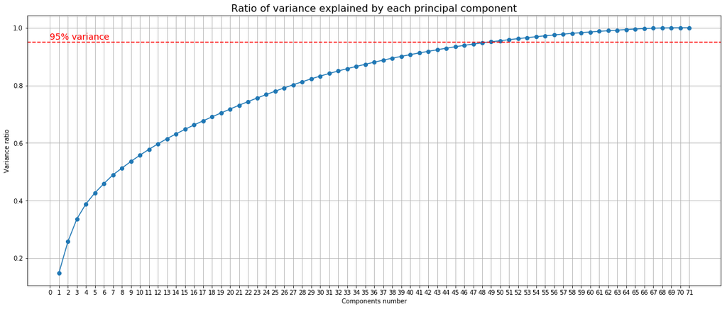

```python
# Investigate the variance accounted for by each principal component.
fig, ax = plt.subplots()

fig.set_figwidth(20)
fig.set_figheight(8)

plt.title('Ratio of variance explained by each principal component', fontsize=16)

x = np.arange(1, 72, step=1) # where x - different components amount
y = np.cumsum(pca.explained_variance_ratio_) # y - cumulative values

plt.plot(x, y, marker='o') # markers for more accurate determination of principal components number

plt.xlabel('Components number')
plt.xticks(np.arange(0, 72, step=1))
plt.ylabel('Variance ratio')

# We will find the number of components at the intersection of this line with the plot (this line is 95% of variance)
plt.axhline(y=0.95, linestyle='--', color='red')
plt.text(0, 0.96, '95% variance', color='red', fontsize=14)

ax.grid()
plt.show()
```

```python
# Re-apply PCA to the data while selecting for number of components to retain.
pca = PCA(n_components=48)
reduced = pca.fit_transform(data_rescaled)
```

```python
data_reduced = pd.DataFrame(reduced)
len(data_reduced.columns)
```

```
48
```

### Discussion 2.2: Perform Dimensionality Reduction

With Scikit-learn, we can get information about the explained variance and plot the cumulative variance. For this goal, in the beginning, I applied PCA for the data and built the plot to demonstrate the ratio of variance by each principle component. Finally, I found the intersection of the 95%-variance line and plot and got the number of components equals 48.

### Step 2.3: Interpret Principal Components

Now that we have our transformed principal components, it's a nice idea to check out the weight of each variable on the first few components to see if they can be interpreted in some fashion.

As a reminder, each principal component is a unit vector that points in the direction of highest variance (after accounting for the variance captured by earlier principal components). The further a weight is from zero, the more the principal component is in the direction of the corresponding feature. If two features have large weights of the same sign (both positive or both negative), then increases in one tend expect to be associated with increases in the other. To contrast, features with different signs can be expected to show a negative correlation: increases in one variable should result in a decrease in the other.

- To investigate the features, you should map each weight to their corresponding feature name, then sort the features according to weight. The most interesting features for each principal component, then, will be those at the beginning and end of the sorted list. Use the data dictionary document to help you understand these most prominent features, their relationships, and what a positive or negative value on the principal component might indicate.
- You should investigate and interpret feature associations from the first three principal components in this substep. To help facilitate this, you should write a function that you can call at any time to print the sorted list of feature weights, for the *i*-th principal component. This might come in handy in the next step of the project, when you interpret the tendencies of the discovered clusters.

```python
dimensions = [f'Dimension {i}' for i in range(1, len(pca.components_)+1)]
components = pd.DataFrame(np.round(pca.components_, 4), columns=clear_ds.columns)
components.index = dimensions
components.head()
```

|  | ALTERSKATEGORIE_GROB | ANREDE_KZ | CJT_GESAMTTYP | FINANZTYP | GEBURTSJAHR | GFK_URLAUBERTYP | GREEN_AVANTGARDE | HEALTH_TYP | LP_LEBENSPHASE_FEIN | LP_FAMILIE_FEIN | ... | PLZ8_BAUMAX | PLZ8_HHZ | PLZ8_GBZ | ARBEIT | ORTSGR_KLS9 | RELAT_AB | PRAEGENDE_JUGENDJAHRE_MOVEMENT | PRAEGENDE_JUGENDJAHRE_DECADE | CAMEO_INTL_2015_WEALTH | CAMEO_INTL_2015_LIFESTATE |
| --- | --- | --- | --- | --- | --- | --- | --- | --- | --- | --- | --- | --- | --- | --- | --- | --- | --- | --- | --- | --- | --- |
| Dimension 1 | -0.0734 | 0.0031 | 0.0284 | -0.0369 | 0.0451 | 0.0635 | -0.1242 | 0.0250 | -0.1606 | -0.1092 | ... | 0.2152 | 0.0327 | -0.1721 | 0.1478 | 0.2023 | 0.1391 | -0.1242 | 0.0529 | 0.2259 | -0.1314 |
| Dimension 2 | 0.2603 | 0.1857 | -0.1218 | 0.0778 | -0.1829 | -0.0408 | -0.0109 | -0.0569 | -0.0308 | -0.0623 | ... | 0.0294 | 0.0003 | -0.0286 | 0.0305 | 0.0367 | 0.0288 | -0.0109 | -0.2299 | 0.0300 | 0.0259 |
| Dimension 3 | 0.1948 | -0.3331 | -0.1018 | 0.1532 | -0.1599 | -0.0451 | 0.0381 | -0.0508 | -0.0153 | -0.0517 | ... | 0.0389 | -0.0089 | -0.0376 | 0.0344 | 0.0282 | 0.0238 | 0.0381 | -0.2021 | 0.0294 | 0.0096 |
| Dimension 4 | -0.0083 | 0.0032 | 0.0704 | 0.0183 | 0.0134 | -0.0399 | 0.3384 | -0.0034 | 0.2101 | 0.2052 | ... | 0.1139 | 0.0679 | -0.0557 | 0.1212 | 0.2929 | 0.1330 | 0.3384 | 0.0186 | -0.0780 | 0.0414 |
| Dimension 5 | 0.0554 | -0.0056 | 0.0469 | 0.0920 | 0.0187 | -0.0131 | -0.1476 | -0.0163 | 0.3398 | 0.3690 | ... | 0.0696 | -0.2753 | -0.2434 | 0.0842 | -0.0565 | 0.0411 | -0.1476 | 0.0201 | 0.1225 | -0.0671 |

5 rows × 71 columns

```python
# HINT: Try defining a function here or in a new cell that you can reuse in the
# other cells.
def get_component(comp):
    dim_comp = {1: 'Dimension 1', 2: 'Dimension 2', 3: 'Dimension 3'}
    sorted_weights = components.T.sort_values(by=dim_comp[comp], ascending=False)[dim_comp[comp]]
    return sorted_weights
```

```python
# Map weights for the first principal component to corresponding feature names
# and then print the linked values, sorted by weight.
get_component(1).head()
```

```
CAMEO_DEUG_2015           0.2300
CAMEO_INTL_2015_WEALTH    0.2259
HH_EINKOMMEN_SCORE        0.2227
PLZ8_BAUMAX               0.2152
ORTSGR_KLS9               0.2023
Name: Dimension 1, dtype: float64
```

```python
get_component(1).tail()
```

```
PLZ8_GBZ         -0.1721
KBA05_GBZ        -0.2305
KBA05_ANTG1      -0.2324
LP_STATUS_FEIN   -0.2376
MOBI_REGIO       -0.2562
Name: Dimension 1, dtype: float64
```

```python
# Map weights for the second principal component to corresponding feature names
# and then print the linked values, sorted by weight.
get_component(2).head()
```

```
SEMIO_ERL               0.2921
ALTERSKATEGORIE_GROB    0.2603
SEMIO_KAEM              0.1932
SEMIO_KRIT              0.1891
ANREDE_KZ               0.1857
Name: Dimension 2, dtype: float64
```

```python
get_component(2).tail()
```

```
SEMIO_TRADV                    -0.2289
PRAEGENDE_JUGENDJAHRE_DECADE   -0.2299
SEMIO_FAM                      -0.2623
SEMIO_REL                      -0.2910
SEMIO_KULT                     -0.2935
Name: Dimension 2, dtype: float64
```

```python
# Map weights for the third principal component to corresponding feature names
# and then print the linked values, sorted by weight.
get_component(3).head()
```

```
SEMIO_VERT              0.3205
SEMIO_SOZ               0.2163
ALTERSKATEGORIE_GROB    0.1948
SEMIO_FAM               0.1688
RETOURTYP_BK_S          0.1651
Name: Dimension 3, dtype: float64
```

```python
get_component(3).tail()
```

```
SEMIO_KRIT   -0.2335
SEMIO_DOM    -0.3001
SEMIO_RAT    -0.3009
SEMIO_KAEM   -0.3057
ANREDE_KZ    -0.3331
Name: Dimension 3, dtype: float64
```

### Discussion 2.3: Interpret Principal Components

The interpretation of the principal components is based on determining which variables are most strongly correlated with each component, that is, which of these numbers are large in magnitude, farther from zero in any direction.

## Step 3: Clustering

### Step 3.1: Apply Clustering to General Population

You've assessed and cleaned the demographics data, then scaled and transformed them. Now, it's time to see how the data clusters in the principal components space. In this substep, you will apply k-means clustering to the dataset and use the average within-cluster distances from each point to their assigned cluster's centroid to decide on a number of clusters to keep.

- Use sklearn's KMeans class to perform k-means clustering on the PCA-transformed data.
- Then, compute the average difference from each point to its assigned cluster's center. **Hint**: The KMeans object's `.score()` method might be useful here, but note that in sklearn, scores tend to be defined so that larger is better. Try applying it to a small, toy dataset, or use an internet search to help your understanding.
- Perform the above two steps for a number of different cluster counts. You can then see how the average distance decreases with an increasing number of clusters. However, each additional cluster provides a smaller net benefit. Use this fact to select a final number of clusters in which to group the data. **Warning**: because of the large size of the dataset, it can take a long time for the algorithm to resolve. The more clusters to fit, the longer the algorithm will take. You should test for cluster counts through at least 10 clusters to get the full picture, but you shouldn't need to test for a number of clusters above about 30.
- Once you've selected a final number of clusters to use, re-fit a KMeans instance to perform the clustering operation. Make sure that you also obtain the cluster assignments for the general demographics data, since you'll be using them in the final Step 3.3.

```python
# data_reduced
# Over a number of different cluster counts...
scores = []
for center in range(2, 10, 1):
    # run k-means clustering on the data and...
    kmeans = KMeans(init='k-means++', n_clusters=center)
    model = kmeans.fit(data_reduced)
    # compute the average within-cluster distances.
    scores.append(model.score(data_reduced))
```

```python
for center in range(10, 20, 1):
    # run k-means clustering on the data and...
    kmeans = KMeans(init='k-means++', n_clusters=center)
    model = kmeans.fit(data_reduced)
    # compute the average within-cluster distances.
    scores.append(model.score(data_reduced))
```

```python
saved_scores = scores
saved_scores
```

[output not shown]

```python
scores_abs = [abs(s) for s in scores]
scores_abs
```

```
[47299189.433057532,
 44669404.11445488,
 42577484.638255715,
 40976002.924798064,
 39878733.574702941,
 38848569.261355877,
 37855652.485086083,
 37145329.894817151,
 36433986.006893151,
 35740996.25074321,
 35224486.516016856,
 34927516.356795534,
 34258818.188244715,
 34254995.074571967,
 33704726.088078104,
 33618999.126081362,
 33102570.290471334,
 32874505.87750278]
```

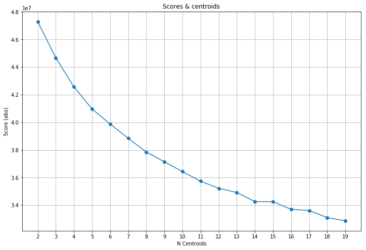

```python
# Investigate the change in within-cluster distance across number of clusters.
# HINT: Use matplotlib's plot function to visualize this relationship.
fig, ax = plt.subplots()
fig.set_figwidth(12)
fig.set_figheight(8)

plt.title('Scores & centroids')
plt.xlabel('N Centroids')
plt.ylabel('Score (abs)')
plt.grid()

plt.xticks(np.arange(0, 20, step=1))
centers = np.arange(2, 20, step=1)
plt.plot(centers, scores_abs, marker='o')
```

```python
# Re-fit the k-means model with the selected number of clusters and obtain
# cluster predictions for the general population demographics data.
kmeans = KMeans(init='k-means++', n_clusters=12)
model = kmeans.fit(data_reduced)
```

### Discussion 3.1: Apply Clustering to General Population

The resulting plot shows the dependency between the number of centroids and corresponding scores. The score increases slowly after 12 centroids. This is easy to see if you calculate the delta-score between points. So let's consider point 12 as an elbow point. **So, the answer is 12 clusters.**

### Step 3.2: Apply All Steps to the Customer Data

Now that you have clusters and cluster centers for the general population, it's time to see how the customer data maps on to those clusters. Take care to not confuse this for re-fitting all of the models to the customer data. Instead, you're going to use the fits from the general population to clean, transform, and cluster the customer data. In the last step of the project, you will interpret how the general population fits apply to the customer data.

- Don't forget when loading in the customers data, that it is semicolon (`;`) delimited.
- Apply the same feature wrangling, selection, and engineering steps to the customer demographics using the `clean_data()` function you created earlier. (You can assume that the customer demographics data has similar meaning behind missing data patterns as the general demographics data.)
- Use the sklearn objects from the general demographics data, and apply their transformations to the customers data. That is, you should not be using a `.fit()` or `.fit_transform()` method to re-fit the old objects, nor should you be creating new sklearn objects! Carry the data through the feature scaling, PCA, and clustering steps, obtaining cluster assignments for all of the data in the customer demographics data.

```python
# Load in the customer demographics data.
customers = pd.read_csv('Udacity_CUSTOMERS_Subset.csv', sep=';')
customers.head()
```

|  | AGER_TYP | ALTERSKATEGORIE_GROB | ANREDE_KZ | CJT_GESAMTTYP | FINANZ_MINIMALIST | FINANZ_SPARER | FINANZ_VORSORGER | FINANZ_ANLEGER | FINANZ_UNAUFFAELLIGER | FINANZ_HAUSBAUER | ... | PLZ8_ANTG1 | PLZ8_ANTG2 | PLZ8_ANTG3 | PLZ8_ANTG4 | PLZ8_BAUMAX | PLZ8_HHZ | PLZ8_GBZ | ARBEIT | ORTSGR_KLS9 | RELAT_AB |
| --- | --- | --- | --- | --- | --- | --- | --- | --- | --- | --- | --- | --- | --- | --- | --- | --- | --- | --- | --- | --- | --- |
| 0 | 2 | 4 | 1 | 5.0 | 5 | 1 | 5 | 1 | 2 | 2 | ... | 3.0 | 3.0 | 1.0 | 0.0 | 1.0 | 5.0 | 5.0 | 1.0 | 2.0 | 1.0 |
| 1 | -1 | 4 | 1 | NaN | 5 | 1 | 5 | 1 | 3 | 2 | ... | NaN | NaN | NaN | NaN | NaN | NaN | NaN | NaN | NaN | NaN |
| 2 | -1 | 4 | 2 | 2.0 | 5 | 1 | 5 | 1 | 4 | 4 | ... | 2.0 | 3.0 | 3.0 | 1.0 | 3.0 | 3.0 | 2.0 | 3.0 | 5.0 | 3.0 |
| 3 | 1 | 4 | 1 | 2.0 | 5 | 1 | 5 | 2 | 1 | 2 | ... | 3.0 | 2.0 | 1.0 | 0.0 | 1.0 | 3.0 | 4.0 | 1.0 | 3.0 | 1.0 |
| 4 | -1 | 3 | 1 | 6.0 | 3 | 1 | 4 | 4 | 5 | 2 | ... | 2.0 | 4.0 | 2.0 | 1.0 | 2.0 | 3.0 | 3.0 | 3.0 | 5.0 | 1.0 |

5 rows × 85 columns

```python
# Apply preprocessing, feature transformation, and clustering from the general
# demographics onto the customer data, obtaining cluster predictions for the
# customer demographics data.
clean_customers = clean_data(customers)
clean_customers.head()
```

|  | ALTERSKATEGORIE_GROB | ANREDE_KZ | CJT_GESAMTTYP | FINANZTYP | GEBURTSJAHR | GFK_URLAUBERTYP | GREEN_AVANTGARDE | HEALTH_TYP | LP_LEBENSPHASE_FEIN | LP_FAMILIE_FEIN | ... | PLZ8_BAUMAX | PLZ8_HHZ | PLZ8_GBZ | ARBEIT | ORTSGR_KLS9 | RELAT_AB | PRAEGENDE_JUGENDJAHRE_MOVEMENT | PRAEGENDE_JUGENDJAHRE_DECADE | CAMEO_INTL_2015_WEALTH | CAMEO_INTL_2015_LIFESTATE |
| --- | --- | --- | --- | --- | --- | --- | --- | --- | --- | --- | --- | --- | --- | --- | --- | --- | --- | --- | --- | --- | --- |
| 0 | 4.0 | 1 | 5.0 | 2 | NaN | 4.0 | 1 | 1.0 | 20.0 | 2.0 | ... | 1.0 | 5.0 | 5.0 | 1.0 | 2.0 | 1.0 | 1.0 | 5.0 | 1.0 | 3.0 |
| 2 | 4.0 | 2 | 2.0 | 2 | NaN | 3.0 | 1 | 2.0 | 13.0 | 1.0 | ... | 3.0 | 3.0 | 2.0 | 3.0 | 5.0 | 3.0 | 1.0 | 5.0 | 3.0 | 4.0 |
| 3 | 4.0 | 1 | 2.0 | 6 | NaN | 10.0 | 0 | 2.0 | 0.0 | 0.0 | ... | 1.0 | 3.0 | 4.0 | 1.0 | 3.0 | 1.0 | 0.0 | 4.0 | 2.0 | 4.0 |
| 4 | 3.0 | 1 | 6.0 | 2 | 1960.0 | 2.0 | 0 | 3.0 | 31.0 | 10.0 | ... | 2.0 | 3.0 | 3.0 | 3.0 | 5.0 | 1.0 | 0.0 | 7.0 | 4.0 | 1.0 |
| 5 | 3.0 | 1 | 4.0 | 5 | NaN | 11.0 | 1 | 3.0 | 17.0 | 2.0 | ... | 1.0 | 5.0 | 5.0 | 3.0 | 7.0 | 5.0 | 1.0 | 5.0 | 3.0 | 4.0 |

5 rows × 71 columns

```python
rescaled_data = rescale_data(clean_customers)
rescaled_data.head()
```

|  | 0 | 1 | 2 | 3 | 4 | 5 | 6 | 7 | 8 | 9 | ... | 61 | 62 | 63 | 64 | 65 | 66 | 67 | 68 | 69 | 70 |
| --- | --- | --- | --- | --- | --- | --- | --- | --- | --- | --- | --- | --- | --- | --- | --- | --- | --- | --- | --- | --- | --- |
| 0 | 0.701599 | -0.702946 | 1.318321 | -1.292379 | -0.096389 | -0.853998 | 1.006968 | -1.256231 | -0.235269 | -0.756947 | ... | -0.463687 | 1.483826 | 1.370614 | -1.806535 | -1.447345 | -1.337313 | 0.988578 | -0.663192 | -1.138271 | -0.277241 |
| 1 | 0.701599 | 1.422585 | -0.688400 | -1.292379 | -0.096389 | -1.174238 | 1.006968 | 0.048557 | -0.776115 | -0.985221 | ... | 1.236406 | -0.670089 | -1.630165 | 0.172663 | -0.055250 | 0.071206 | 0.988578 | -0.663192 | 0.288015 | 0.470155 |
| 2 | 0.701599 | -0.702946 | -0.688400 | 1.033913 | -0.096389 | 1.067441 | -0.993081 | 0.048557 | -1.780544 | -1.213495 | ... | -0.463687 | -0.670089 | 0.370354 | -1.806535 | -0.983313 | -1.337313 | -1.011554 | -1.409132 | -0.425128 | 0.470155 |
| 3 | -0.668422 | -0.702946 | 1.987228 | -1.292379 | 0.877521 | -1.494478 | -0.993081 | 1.353344 | 0.614632 | 1.069247 | ... | 0.386360 | -0.670089 | -0.629905 | 0.172663 | -0.055250 | -1.337313 | -1.011554 | 0.828687 | 1.001157 | -1.772032 |
| 4 | -0.668422 | -0.702946 | 0.649414 | 0.452340 | -0.096389 | 1.387681 | 1.006968 | 1.353344 | -0.467060 | -0.756947 | ... | -0.463687 | 1.483826 | 1.370614 | 0.172663 | 0.872813 | 1.479726 | 0.988578 | -0.663192 | 0.288015 | 0.470155 |

5 rows × 71 columns

```python
transformed_data = pd.DataFrame(pca.transform(rescaled_data))
transformed_data.head()
```

|  | 0 | 1 | 2 | 3 | 4 | 5 | 6 | 7 | 8 | 9 | ... | 38 | 39 | 40 | 41 | 42 | 43 | 44 | 45 | 46 | 47 |
| --- | --- | --- | --- | --- | --- | --- | --- | --- | --- | --- | --- | --- | --- | --- | --- | --- | --- | --- | --- | --- | --- |
| 0 | -3.641186 | -0.651248 | 2.768137 | -0.631053 | -2.713358 | 2.030136 | 0.090706 | -0.678427 | 0.692088 | -0.724908 | ... | 0.758260 | -0.467931 | 0.251474 | 0.365184 | -0.531334 | -0.072527 | -0.758816 | 0.232354 | -1.583891 | 0.420306 |
| 1 | 1.122136 | 4.606888 | -0.907310 | 0.691429 | -1.049595 | -2.062374 | 0.068617 | 0.525529 | -1.243216 | -0.019118 | ... | 0.022800 | 0.300564 | 0.134381 | -1.003467 | 0.058221 | 0.387493 | -1.015562 | -1.250849 | -1.150058 | 0.594537 |
| 2 | -1.413225 | -1.024498 | 1.894069 | -4.239795 | -1.060489 | 0.001273 | 1.107354 | 0.309550 | -1.206217 | -0.776115 | ... | -0.492721 | -0.448620 | -0.199431 | -0.132138 | 0.679786 | -0.062293 | 0.234736 | -0.034765 | 0.158841 | -0.811242 |
| 3 | 3.295361 | -2.863665 | -1.308662 | -0.125642 | 2.822491 | 0.656449 | -2.556132 | 0.376152 | 0.939511 | 0.603681 | ... | -0.104446 | -1.300423 | -0.376676 | 0.095820 | -0.075052 | -0.083253 | 0.280675 | 0.460656 | 0.312358 | -0.653703 |
| 4 | -0.067768 | -0.971887 | 0.941852 | 0.863234 | -2.563022 | 0.272188 | -2.152658 | -0.265378 | 0.375696 | 1.768580 | ... | -0.697483 | 0.531554 | -0.098984 | -0.288888 | -0.889040 | 0.209280 | -0.093711 | -0.619048 | 1.011659 | -0.857310 |

5 rows × 48 columns

```python
transformed_data['Segment'] = pd.Series(kmeans.predict(transformed_data))
```

```python
transformed_data.head()
```

|  | 0 | 1 | 2 | 3 | 4 | 5 | 6 | 7 | 8 | 9 | ... | 39 | 40 | 41 | 42 | 43 | 44 | 45 | 46 | 47 | Segment |
| --- | --- | --- | --- | --- | --- | --- | --- | --- | --- | --- | --- | --- | --- | --- | --- | --- | --- | --- | --- | --- | --- |
| 0 | -3.641186 | -0.651248 | 2.768137 | -0.631053 | -2.713358 | 2.030136 | 0.090706 | -0.678427 | 0.692088 | -0.724908 | ... | -0.467931 | 0.251474 | 0.365184 | -0.531334 | -0.072527 | -0.758816 | 0.232354 | -1.583891 | 0.420306 | 6 |
| 1 | 1.122136 | 4.606888 | -0.907310 | 0.691429 | -1.049595 | -2.062374 | 0.068617 | 0.525529 | -1.243216 | -0.019118 | ... | 0.300564 | 0.134381 | -1.003467 | 0.058221 | 0.387493 | -1.015562 | -1.250849 | -1.150058 | 0.594537 | 1 |
| 2 | -1.413225 | -1.024498 | 1.894069 | -4.239795 | -1.060489 | 0.001273 | 1.107354 | 0.309550 | -1.206217 | -0.776115 | ... | -0.448620 | -0.199431 | -0.132138 | 0.679786 | -0.062293 | 0.234736 | -0.034765 | 0.158841 | -0.811242 | 6 |
| 3 | 3.295361 | -2.863665 | -1.308662 | -0.125642 | 2.822491 | 0.656449 | -2.556132 | 0.376152 | 0.939511 | 0.603681 | ... | -1.300423 | -0.376676 | 0.095820 | -0.075052 | -0.083253 | 0.280675 | 0.460656 | 0.312358 | -0.653703 | 5 |
| 4 | -0.067768 | -0.971887 | 0.941852 | 0.863234 | -2.563022 | 0.272188 | -2.152658 | -0.265378 | 0.375696 | 1.768580 | ... | 0.531554 | -0.098984 | -0.288888 | -0.889040 | 0.209280 | -0.093711 | -0.619048 | 1.011659 | -0.857310 | 7 |

5 rows × 49 columns

```python
customers_data = transformed_data
```

**Let's process the subset_1 with a lot of missing data**

```python
reincoded_ss = reincode_data(subset_1)
reincoded_ss.head()
```

|  | ALTERSKATEGORIE_GROB | ANREDE_KZ | CJT_GESAMTTYP | FINANZTYP | GEBURTSJAHR | GFK_URLAUBERTYP | GREEN_AVANTGARDE | HEALTH_TYP | LP_LEBENSPHASE_FEIN | LP_FAMILIE_FEIN | ... | PLZ8_BAUMAX | PLZ8_HHZ | PLZ8_GBZ | ARBEIT | ORTSGR_KLS9 | RELAT_AB | PRAEGENDE_JUGENDJAHRE_MOVEMENT | PRAEGENDE_JUGENDJAHRE_DECADE | CAMEO_INTL_2015_WEALTH | CAMEO_INTL_2015_LIFESTATE |
| --- | --- | --- | --- | --- | --- | --- | --- | --- | --- | --- | --- | --- | --- | --- | --- | --- | --- | --- | --- | --- | --- |
| 0 | 2.0 | 1 | 2.0 | 4 | NaN | 10.0 | 0 | NaN | 15.0 | 2.0 | ... | NaN | NaN | NaN | NaN | NaN | NaN | NaN | NaN | NaN | NaN |
| 11 | 2.0 | 1 | 6.0 | 4 | NaN | 5.0 | 0 | NaN | 0.0 | 0.0 | ... | NaN | NaN | NaN | NaN | NaN | NaN | NaN | NaN | NaN | NaN |
| 14 | 3.0 | 1 | 6.0 | 4 | NaN | 5.0 | 0 | NaN | 0.0 | 0.0 | ... | NaN | NaN | NaN | NaN | NaN | NaN | NaN | NaN | NaN | NaN |
| 17 | 2.0 | 1 | 6.0 | 4 | NaN | 5.0 | 0 | NaN | 0.0 | 0.0 | ... | NaN | NaN | NaN | NaN | NaN | NaN | NaN | NaN | NaN | NaN |
| 24 | 3.0 | 2 | 6.0 | 4 | NaN | 5.0 | 0 | NaN | 0.0 | 0.0 | ... | NaN | NaN | NaN | NaN | NaN | NaN | NaN | NaN | NaN | NaN |

5 rows × 71 columns

```python
rescaled_subset = rescale_data(reincoded_ss)
rescaled_subset.head()
```

|  | 0 | 1 | 2 | 3 | 4 | 5 | 6 | 7 | 8 | 9 | ... | 61 | 62 | 63 | 64 | 65 | 66 | 67 | 68 | 69 | 70 |
| --- | --- | --- | --- | --- | --- | --- | --- | --- | --- | --- | --- | --- | --- | --- | --- | --- | --- | --- | --- | --- | --- |
| 0 | -0.497145 | -1.056503 | -1.666611 | 0.359774 | 0.008694 | 1.280444 | -0.007324 | 0.113087 | 0.560830 | -0.018506 | ... | 0.0 | 0.003275 | -0.004394 | 0.00345 | 0.001708 | 0.004359 | -0.007324 | -0.090951 | 0.013466 | -0.00337 |
| 1 | -0.497145 | -1.056503 | 0.766607 | 0.359774 | 0.008694 | -0.460804 | -0.007324 | 0.113087 | -0.677139 | -0.588467 | ... | 0.0 | 0.003275 | -0.004394 | 0.00345 | 0.001708 | 0.004359 | -0.007324 | -0.090951 | 0.013466 | -0.00337 |
| 2 | 0.654399 | -1.056503 | 0.766607 | 0.359774 | 0.008694 | -0.460804 | -0.007324 | 0.113087 | -0.677139 | -0.588467 | ... | 0.0 | 0.003275 | -0.004394 | 0.00345 | 0.001708 | 0.004359 | -0.007324 | -0.090951 | 0.013466 | -0.00337 |
| 3 | -0.497145 | -1.056503 | 0.766607 | 0.359774 | 0.008694 | -0.460804 | -0.007324 | 0.113087 | -0.677139 | -0.588467 | ... | 0.0 | 0.003275 | -0.004394 | 0.00345 | 0.001708 | 0.004359 | -0.007324 | -0.090951 | 0.013466 | -0.00337 |
| 4 | 0.654399 | 0.946519 | 0.766607 | 0.359774 | 0.008694 | -0.460804 | -0.007324 | 0.113087 | -0.677139 | -0.588467 | ... | 0.0 | 0.003275 | -0.004394 | 0.00345 | 0.001708 | 0.004359 | -0.007324 | -0.090951 | 0.013466 | -0.00337 |

5 rows × 71 columns

```python
transformed_ss = pd.DataFrame(pca.transform(rescaled_subset))
transformed_ss.head()
```

|  | 0 | 1 | 2 | 3 | 4 | 5 | 6 | 7 | 8 | 9 | ... | 38 | 39 | 40 | 41 | 42 | 43 | 44 | 45 | 46 | 47 |
| --- | --- | --- | --- | --- | --- | --- | --- | --- | --- | --- | --- | --- | --- | --- | --- | --- | --- | --- | --- | --- | --- |
| 0 | 0.441190 | 0.411995 | 0.569269 | -0.288547 | -0.402833 | -0.064923 | -0.078309 | 0.098745 | 0.066557 | -0.235125 | ... | -0.270167 | 0.387372 | -0.019967 | 0.327811 | -0.326408 | 0.068284 | -0.501233 | 0.687525 | 0.442396 | -0.118372 |
| 1 | 0.172291 | -0.156845 | 0.060521 | -0.174964 | -0.690385 | -0.435166 | 0.126791 | 0.060110 | -0.413998 | 0.210547 | ... | -0.170464 | 0.320515 | 0.036972 | 0.225397 | -0.115499 | 0.126199 | -0.467003 | -0.212671 | -0.125525 | -0.109494 |
| 2 | 0.087811 | 0.142884 | 0.284853 | -0.184548 | -0.626605 | -0.381959 | 0.091310 | 0.020808 | -0.357964 | 0.243576 | ... | -0.061808 | 0.233139 | 0.039894 | 0.247460 | -0.114431 | 0.138906 | -0.462995 | -0.323042 | -0.047800 | -0.071316 |
| 3 | 0.172291 | -0.156845 | 0.060521 | -0.174964 | -0.690385 | -0.435166 | 0.126791 | 0.060110 | -0.413998 | 0.210547 | ... | -0.170464 | 0.320515 | 0.036972 | 0.225397 | -0.115499 | 0.126199 | -0.467003 | -0.212671 | -0.125525 | -0.109494 |
| 4 | 0.094067 | 0.514900 | -0.382297 | -0.178160 | -0.637892 | -0.399899 | 0.162404 | 0.055095 | -0.320861 | 0.040602 | ... | -0.213436 | 0.373930 | 0.048306 | 0.298583 | 0.027872 | 0.084963 | -0.392541 | -0.252927 | -0.118929 | 0.110984 |

5 rows × 48 columns

```python
transformed_ss['Segment'] = pd.Series(kmeans.predict(transformed_ss))
```

```python
missed_ss = transformed_ss
```

### Step 3.3: Compare Customer Data to Demographics Data

At this point, you have clustered data based on demographics of the general population of Germany, and seen how the customer data for a mail-order sales company maps onto those demographic clusters. In this final substep, you will compare the two cluster distributions to see where the strongest customer base for the company is.

Consider the proportion of persons in each cluster for the general population, and the proportions for the customers. If we think the company's customer base to be universal, then the cluster assignment proportions should be fairly similar between the two. If there are only particular segments of the population that are interested in the company's products, then we should see a mismatch from one to the other. If there is a higher proportion of persons in a cluster for the customer data compared to the general population (e.g. 5% of persons are assigned to a cluster for the general population, but 15% of the customer data is closest to that cluster's centroid) then that suggests the people in that cluster to be a target audience for the company. On the other hand, the proportion of the data in a cluster being larger in the general population than the customer data (e.g. only 2% of customers closest to a population centroid that captures 6% of the data) suggests that group of persons to be outside of the target demographics.

Take a look at the following points in this step:

- Compute the proportion of data points in each cluster for the general population and the customer data. Visualizations will be useful here: both for the individual dataset proportions, but also to visualize the ratios in cluster representation between groups. Seaborn's [`countplot()`](https://seaborn.pydata.org/generated/seaborn.countplot.html) or [`barplot()`](https://seaborn.pydata.org/generated/seaborn.barplot.html) function could be handy.
  - Recall the analysis you performed in step 1.1.3 of the project, where you separated out certain data points from the dataset if they had more than a specified threshold of missing values. If you found that this group was qualitatively different from the main bulk of the data, you should treat this as an additional data cluster in this analysis. Make sure that you account for the number of data points in this subset, for both the general population and customer datasets, when making your computations!
- Which cluster or clusters are overrepresented in the customer dataset compared to the general population? Select at least one such cluster and infer what kind of people might be represented by that cluster. Use the principal component interpretations from step 2.3 or look at additional components to help you make this inference. Alternatively, you can use the `.inverse_transform()` method of the PCA and StandardScaler objects to transform centroids back to the original data space and interpret the retrieved values directly.
- Perform a similar investigation for the underrepresented clusters. Which cluster or clusters are underrepresented in the customer dataset compared to the general population, and what kinds of people are typified by these clusters?

```python
# Compare the proportion of data in each cluster for the customer data to the
# proportion of data in each cluster for the general population.

# Distribution by segment: demographic data
dem_clusters_dist = pd.Series(kmeans.labels_).value_counts().sort_index() / len(data_reduced)
dem_clusters_dist
```

```
0     0.073100
1     0.113081
2     0.071428
3     0.103577
4     0.074917
5     0.090071
6     0.109431
7     0.113852
8     0.074706
9     0.098449
10    0.003914
11    0.073475
dtype: float64
```

```python
# Distribution by segments: customers data
cust_clusters_dist = customers_data.groupby('Segment').size() / len(customers_data)
cust_clusters_dist
```

```
Segment
0     0.068932
1     0.095470
2     0.060168
3     0.069200
4     0.186756
5     0.035648
6     0.179114
7     0.139289
8     0.063012
9     0.070837
10    0.003161
11    0.028415
dtype: float64
```

```python
ss_clusters_dist = missed_ss.groupby('Segment').size() / len(missed_ss)
ss_clusters_dist
```

```
Segment
0     0.025679
1     0.263400
2     0.000182
3     0.035440
4     0.003561
5     0.022182
6     0.091283
7     0.332672
8     0.004226
9     0.197743
10    0.000890
11    0.022740
dtype: float64
```

```
<Container object of 12 artists>
```

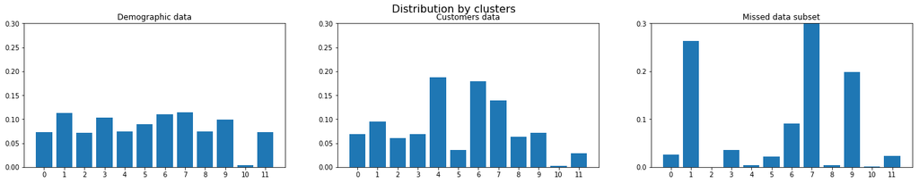

```python
fig, axs = plt.subplots(1, 3)
fig.suptitle(f'Distribution by clusters', fontsize=16)
fig.set_figwidth(24)
fig.set_figheight(4)

axs[0].set_title('Demographic data')
axs[1].set_title('Customers data')
axs[2].set_title('Missed data subset')

plt.yticks(np.arange(0, 1, step=0.1))
axs[0].set_xticks(range(0, 12, 1))
axs[1].set_xticks(range(0, 12, 1))
axs[2].set_xticks(range(0, 12, 1))

axs[0].set_ylim(0, 0.3)
axs[1].set_ylim(0, 0.3)
axs[2].set_ylim(0, 0.3)

axs[0].bar(x=dem_clusters_dist.index, height=dem_clusters_dist.values)
axs[1].bar(x=cust_clusters_dist.index, height=cust_clusters_dist.values)
axs[2].bar(x=ss_clusters_dist.index, height=ss_clusters_dist.values)
```

```python
# What kinds of people are part of a cluster that is overrepresented in the
# customer data compared to the general population?
cust_clusters_dist[dem_clusters_dist < cust_clusters_dist]
```

```
Segment
4    0.186756
6    0.179114
7    0.139289
dtype: float64
```

```python
# What kinds of people are part of a cluster that is underrepresented in the
# customer data compared to the general population?
cust_clusters_dist[dem_clusters_dist > cust_clusters_dist]
```

```
Segment
0     0.068932
1     0.095470
2     0.060168
3     0.069200
5     0.035648
8     0.063012
9     0.070837
10    0.003161
11    0.028415
dtype: float64
```

```python
centroids = scaler.inverse_transform(pca.inverse_transform(kmeans.cluster_centers_))
centroids_dict = {f'C{k+1}' : c for k, c in enumerate(centroids)}
centroids_dict['Feature'] = clean_customers.columns
clusters_df = pd.DataFrame(centroids_dict)
clusters_df.set_index('Feature', inplace=True)
clusters_df.head()
```

| Feature | C1 | C2 | C3 | C4 | C5 | C6 | C7 | C8 | C9 | C10 | C11 | C12 |
| --- | --- | --- | --- | --- | --- | --- | --- | --- | --- | --- | --- | --- |
| ALTERSKATEGORIE_GROB | 1.737723 | 3.473642 | 3.346589 | 3.480887 | 3.296703 | 1.537189 | 3.303595 | 3.304970 | 3.345721 | 1.684614 | 3.093848 | 1.709205 |
| ANREDE_KZ | 0.969209 | 1.987175 | 1.575149 | 1.943829 | 1.045676 | 2.005435 | 1.090702 | 1.035973 | 1.969151 | 1.955800 | 1.440250 | 0.959804 |
| CJT_GESAMTTYP | 4.341776 | 3.062790 | 3.313109 | 3.091530 | 3.190872 | 4.064083 | 3.013416 | 3.455613 | 3.468957 | 4.027727 | 3.338498 | 3.921406 |
| FINANZTYP | 3.291902 | 3.946242 | 4.383041 | 4.102082 | 4.579971 | 2.091674 | 4.550347 | 4.877146 | 3.980047 | 2.679587 | 4.121167 | 2.872866 |
| GEBURTSJAHR | 1978.645642 | 1962.402411 | 1963.603865 | 1962.684930 | 1961.827065 | 1975.307347 | 1962.459323 | 1963.905243 | 1962.666609 | 1976.673792 | 1963.767979 | 1976.201186 |

```python
target_centroid = 4
target_cluster = clusters_df[f'C{target_centroid}']
```

```python
target_cluster[get_component(1).head().index]
```

```
CAMEO_DEUG_2015           4.243613
CAMEO_INTL_2015_WEALTH    2.508076
HH_EINKOMMEN_SCORE        4.064970
PLZ8_BAUMAX               1.037921
ORTSGR_KLS9               3.152128
Name: C4, dtype: float64
```

```python
target_cluster[get_component(1).tail().index]
```

```
PLZ8_GBZ          3.795973
KBA05_GBZ         3.999868
KBA05_ANTG1       2.299754
LP_STATUS_FEIN    6.614888
MOBI_REGIO        3.950339
Name: C4, dtype: float64
```

```python
target_centroid = 6
target_cluster = clusters_df[f'C{target_centroid}']
```

```python
target_cluster[get_component(1).head().index]
```

```
CAMEO_DEUG_2015           7.540541
CAMEO_INTL_2015_WEALTH    4.408037
HH_EINKOMMEN_SCORE        5.576164
PLZ8_BAUMAX               3.027791
ORTSGR_KLS9               6.889135
Name: C6, dtype: float64
```

```python
target_cluster[get_component(1).tail().index]
```

```
PLZ8_GBZ          2.734402
KBA05_GBZ         2.159948
KBA05_ANTG1       0.382333
LP_STATUS_FEIN    1.925494
MOBI_REGIO        1.781252
Name: C6, dtype: float64
```

### Discussion 3.3: Compare Customer Data to Demographics Data

The company's client base is not universal, since the proportions of the distribution of clusters between them are not the same. It can be concluded that only certain segments of the population are interested in the company's products. For people in clusters 4, 6, 7, the proportion of customer data is higher than in the general population. This assumes that the people in these clusters are the target audience for the company.

Now let's investigate people from our target audience.

### What about centroid №7

Let's take a look at the third bar. We can see that a lot of data that tend to be missed occurred in the 7th cluster. So we won't analyze it and consider 4 and 6 clusters as target audiences.

> Congratulations on making it this far in the project! Before you finish, make sure to check through the entire notebook from top to bottom to make sure that your analysis follows a logical flow and all of your findings are documented in **Discussion** cells. Once you've checked over all of your work, you should export the notebook as an HTML document to submit for evaluation. You can do this from the menu, navigating to **File -> Download as -> HTML (.html)**. You will submit both that document and this notebook for your project submission.